# NCDB Parotid ACC 2015

All

Jason Brant

August 23, 2018

**Note: To hide the code from this document, click the button in the upper right corner.**

```r
col.width <- c(37, 10, 1, 1, 3, 1, 2, 1, 2, 1, 1, 1, 1, 1, 1, 8, 2, 2, 2, 4, 4, 1, 4, 1, 1, 1, 3, 2, 2, 8,
               2, 5, 5, 5, 4, 5, 5, 5, 4, 2, 1, 2, 1, 3, 1, 1, 1, 1, 1, 1, 3, 3, 3, 3, 3, 3, 3, 3, 3, 3, 3,
               3, 3, 3, 3, 3, 3, 3, 3, 3, 3, 3, 3, 3, 3, 6, 8, 8, 8, 2, 1, 1, 1, 1, 8, 1, 1, 8, 1, 1, 2,
               2, 5, 2, 5, 3, 1, 3, 1, 8, 8, 2, 8, 2, 8, 2, 2, 1, 8, 1, 1, 1, 1, 1, 8, 1, 2, 2, 2, 2, 2,
               1, 1, 1, 2, 1)
col.names.abr <- c("PUF_CASE_ID", "PUF_FACILITY_ID", "FACILITY_TYPE_CD",  "FACILITY_LOCATION_CD", "AGE", "SEX", "RACE",
                   "SPANISH_HISPANIC_ORIGIN", "INSURANCE_STATUS", "MED_INC_QUAR_00", "NO_HSD_QUAR_00", "UR_CD_03",
                   "MED_INC_QUAR_12", "NO_HSD_QUAR_12", "UR_CD_13", "CROWFLY", "CDCC_TOTAL", "SEQUENCE_NUMBER",
                   "CLASS_OF_CASE", "YEAR_OF_DIAGNOSIS", "PRIMARY_SITE",  "LATERALITY", "HISTOLOGY", "BEHAVIOR",
                   "GRADE", "DIAGNOSTIC_CONFIRMATION", "TUMOR_SIZE", "REGIONAL_NODES_POSITIVE",
                   "REGIONAL_NODES_EXAMINED", "DX_STAGING_PROC_DAYS", "RX_SUMM_DXSTG_PROC", "TNM_CLIN_T",
                   "TNM_CLIN_N", "TNM_CLIN_M", "TNM_CLIN_STAGE_GROUP", "TNM_PATH_T", "TNM_PATH_N", "TNM_PATH_M",
                   "TNM_PATH_STAGE_GROUP", "TNM_EDITION_NUMBER", "ANALYTIC_STAGE_GROUP", "CS_METS_AT_DX",
                   "CS_METS_EVAL", "CS_EXTENSION", "CS_TUMOR_SIZEEXT_EVAL", "CS_METS_DX_BONE",
                   "CS_METS_DX_BRAIN", "CS_METS_DX_LIVER", "CS_METS_DX_LUNG", "LYMPH_VASCULAR_INVASION",
                   "CS_SITESPECIFIC_FACTOR_1", "CS_SITESPECIFIC_FACTOR_2", "CS_SITESPECIFIC_FACTOR_3",
                   "CS_SITESPECIFIC_FACTOR_4", "CS_SITESPECIFIC_FACTOR_5", "CS_SITESPECIFIC_FACTOR_6",
                   "CS_SITESPECIFIC_FACTOR_7", "CS_SITESPECIFIC_FACTOR_8", "CS_SITESPECIFIC_FACTOR_9",
                   "CS_SITESPECIFIC_FACTOR_10", "CS_SITESPECIFIC_FACTOR_11", "CS_SITESPECIFIC_FACTOR_12",
                   "CS_SITESPECIFIC_FACTOR_13", "CS_SITESPECIFIC_FACTOR_14", "CS_SITESPECIFIC_FACTOR_15",
                   "CS_SITESPECIFIC_FACTOR_16", "CS_SITESPECIFIC_FACTOR_17", "CS_SITESPECIFIC_FACTOR_18",
                   "CS_SITESPECIFIC_FACTOR_19", "CS_SITESPECIFIC_FACTOR_20", "CS_SITESPECIFIC_FACTOR_21",
                   "CS_SITESPECIFIC_FACTOR_22", "CS_SITESPECIFIC_FACTOR_23", "CS_SITESPECIFIC_FACTOR_24",
                   "CS_SITESPECIFIC_FACTOR_25", "CS_VERSION_LATEST", "DX_RX_STARTED_DAYS",
                   "DX_SURG_STARTED_DAYS", "DX_DEFSURG_STARTED_DAYS", "RX_SUMM_SURG_PRIM_SITE",
                   "RX_HOSP_SURG_APPR_2010", "RX_SUMM_SURGICAL_MARGINS", "RX_SUMM_SCOPE_REG_LN_SUR",
                   "RX_SUMM_SURG_OTH_REGDIS", "SURG_DISCHARGE_DAYS", "READM_HOSP_30_DAYS",
                   "REASON_FOR_NO_SURGERY", "DX_RAD_STARTED_DAYS", "RX_SUMM_RADIATION", "RAD_LOCATION_OF_RX",
                   "RAD_TREAT_VOL", "RAD_REGIONAL_RX_MODALITY", "RAD_REGIONAL_DOSE_CGY",
                   "RAD_BOOST_RX_MODALITY", "RAD_BOOST_DOSE_CGY", "RAD_NUM_TREAT_VOL",
                   "RX_SUMM_SURGRAD_SEQ", "RAD_ELAPSED_RX_DAYS", "REASON_FOR_NO_RADIATION",
                   "DX_SYSTEMIC_STARTED_DAYS", "DX_CHEMO_STARTED_DAYS", "RX_SUMM_CHEMO",
                   "DX_HORMONE_STARTED_DAYS", "RX_SUMM_HORMONE", "DX_IMMUNO_STARTED_DAYS",
                   "RX_SUMM_IMMUNOTHERAPY", "RX_SUMM_TRNSPLNT_ENDO", "RX_SUMM_SYSTEMIC_SUR_SEQ",
                   "DX_OTHER_STARTED_DAYS", "RX_SUMM_OTHER", "PALLIATIVE_CARE", "RX_SUMM_TREATMENT_STATUS",
                   "PUF_30_DAY_MORT_CD", "PUF_90_DAY_MORT_CD", "DX_LASTCONTACT_DEATH_MONTHS",
                   "PUF_VITAL_STATUS", "RX_HOSP_SURG_PRIM_SITE", "RX_HOSP_CHEMO", "RX_HOSP_IMMUNOTHERAPY",
                   "RX_HOSP_HORMONE", "RX_HOSP_OTHER", "PUF_MULT_SOURCE", "REFERENCE_DATE_FLAG",
                   "RX_SUMM_SCOPE_REG_LN_2012", "RX_HOSP_DXSTG_PROC", "PALLIATIVE_CARE_HOSP")
#Read in data for each subsite
bone.joint <- read_fwf('I:/Brant/Research/NCDB/Data/Data_2017/NCDB_PUF_DATA_Nov-07-2017/NCDBPUF_BoneJont.3.2015.0.dat',
                       fwf_widths(col.width, col_names = col.names.abr),
                       col_types = cols(.default = col_character()))
brain <- read_fwf('I:/Brant/Research/NCDB/Data/Data_2017/NCDB_PUF_DATA_Nov-07-2017/NCDBPUF_Brain.3.2015.0.dat',
                       fwf_widths(col.width, col_names = col.names.abr),
                       col_types = cols(.default = col_character()))
cns <- read_fwf('I:/Brant/Research/NCDB/Data/Data_2017/NCDB_PUF_DATA_Nov-07-2017/NCDBPUF_CNS.3.2015.0.dat',
                       fwf_widths(col.width, col_names = col.names.abr),
                       col_types = cols(.default = col_character()))
gum.ot.mth <- read_fwf('I:/Brant/Research/NCDB/Data/Data_2017/NCDB_PUF_DATA_Nov-07-2017/NCDBPUF_GumOtMth.3.2015.0.dat',
                       fwf_widths(col.width, col_names = col.names.abr),
                       col_types = cols(.default = col_character()))
hypophar <- read_fwf('I:/Brant/Research/NCDB/Data/Data_2017/NCDB_PUF_DATA_Nov-07-2017/NCDBPUF_Hypophar.3.2015.0.dat',
                       fwf_widths(col.width, col_names = col.names.abr),
                       col_types = cols(.default = col_character()))
larynx <- read_fwf('I:/Brant/Research/NCDB/Data/Data_2017/NCDB_PUF_DATA_Nov-07-2017/NCDBPUF_Larynx.3.2015.0.dat',
                       fwf_widths(col.width, col_names = col.names.abr),
                       col_types = cols(.default = col_character()))
lip <- read_fwf('I:/Brant/Research/NCDB/Data/Data_2017/NCDB_PUF_DATA_Nov-07-2017/NCDBPUF_Lip.3.2015.0.dat',
                       fwf_widths(col.width, col_names = col.names.abr),
                       col_types = cols(.default = col_character()))
melanoma <- read_fwf('I:/Brant/Research/NCDB/Data/Data_2017/NCDB_PUF_DATA_Nov-07-2017/NCDBPUF_Melanoma.3.2015.0.dat',
                       fwf_widths(col.width, col_names = col.names.abr),
                       col_types = cols(.default = col_character()))
fom <- read_fwf('I:/Brant/Research/NCDB/Data/Data_2017/NCDB_PUF_DATA_Nov-07-2017/NCDBPUF_MouthFlr.3.2015.0.dat',
                       fwf_widths(col.width, col_names = col.names.abr),
                       col_types = cols(.default = col_character()))
nasal <- read_fwf('I:/Brant/Research/NCDB/Data/Data_2017/NCDB_PUF_DATA_Nov-07-2017/NCDBPUF_Nasal.3.2015.0.dat',
                       fwf_widths(col.width, col_names = col.names.abr),
                       col_types = cols(.default = col_character()))
nasophar <- read_fwf('I:/Brant/Research/NCDB/Data/Data_2017/NCDB_PUF_DATA_Nov-07-2017/NCDBPUF_Nasophar.3.2015.0.dat',
                       fwf_widths(col.width, col_names = col.names.abr),
                       col_types = cols(.default = col_character()))
orophar <- read_fwf('I:/Brant/Research/NCDB/Data/Data_2017/NCDB_PUF_DATA_Nov-07-2017/NCDBPUF_Orophary.3.2015.0.dat',
                       fwf_widths(col.width, col_names = col.names.abr),
                       col_types = cols(.default = col_character()))
oth.endo <- read_fwf('I:/Brant/Research/NCDB/Data/Data_2017/NCDB_PUF_DATA_Nov-07-2017/NCDBPUF_OtEndocr.3.2015.0.dat',
                       fwf_widths(col.width, col_names = col.names.abr),
                       col_types = cols(.default = col_character()))
skin <- read_fwf('I:/Brant/Research/NCDB/Data/Data_2017/NCDB_PUF_DATA_Nov-07-2017/NCDBPUF_OtSkin.3.2015.0.dat',
                       fwf_widths(col.width, col_names = col.names.abr),
                       col_types = cols(.default = col_character()))
pharynx <- read_fwf('I:/Brant/Research/NCDB/Data/Data_2017/NCDB_PUF_DATA_Nov-07-2017/NCDBPUF_Pharynx.3.2015.0.dat',
                       fwf_widths(col.width, col_names = col.names.abr),
                       col_types = cols(.default = col_character()))
saliv.gland <- read_fwf('I:/Brant/Research/NCDB/Data/Data_2017/NCDB_PUF_DATA_Nov-07-2017/NCDBPUF_SalivGld.3.2015.0.dat',
                       fwf_widths(col.width, col_names = col.names.abr),
                       col_types = cols(.default = col_character()))
thyroid <- read_fwf('I:/Brant/Research/NCDB/Data/Data_2017/NCDB_PUF_DATA_Nov-07-2017/NCDBPUF_Thyroid.3.2015.0.dat',
                       fwf_widths(col.width, col_names = col.names.abr),
                       col_types = cols(.default = col_character()))
tongue <- read_fwf('I:/Brant/Research/NCDB/Data/Data_2017/NCDB_PUF_DATA_Nov-07-2017/NCDBPUF_Tongue.3.2015.0.dat',
                       fwf_widths(col.width, col_names = col.names.abr),
                       col_types = cols(.default = col_character()))
tonsil <- read_fwf('I:/Brant/Research/NCDB/Data/Data_2017/NCDB_PUF_DATA_Nov-07-2017/NCDBPUF_Tonsil.3.2015.0.dat',
                       fwf_widths(col.width, col_names = col.names.abr),
                       col_types = cols(.default = col_character()))
trach.med <- read_fwf('I:/Brant/Research/NCDB/Data/Data_2017/NCDB_PUF_DATA_Nov-07-2017/NCDBPUF_TrachMed.3.2015.0.dat',
                       fwf_widths(col.width, col_names = col.names.abr),
                       col_types = cols(.default = col_character()))
#Combine data for all subsites
dat <- bind_rows(bone.joint, brain, cns, gum.ot.mth, hypophar, larynx, lip, melanoma, fom, nasal, nasophar, orophar,
                 oth.endo, skin, pharynx, saliv.gland, thyroid, tongue, tonsil, trach.med)
rm(bone.joint, brain, cns, gum.ot.mth, hypophar, larynx, lip, melanoma, fom, nasal, nasophar, orophar,
                 oth.endo, skin, pharynx, saliv.gland, thyroid, tongue, tonsil, trach.med)
prim_site_text <- data_frame(PRIMARY_SITE = c("C030", "C031", "C062", "C039", "C050", "C051", "C052", "C058", "C059", "C068",
               "C069", "C060", "C061", "C129", "C130", "C131", "C132", "C138", "C139", "C320",
               "C321", "C322", "C323", "C328", "C329", "C000", "C003", "C001", "C004", "C006",
               "C002", "C005", "C008", "C009", "C440", "C442", "C443", "C444", "C445", "C446",
               "C447", "C448", "C449", "C441", "C040", "C041", "C048", "C049", "C300", "C301",
               "C310", "C311", "C312", "C313", "C318", "C319", "C110", "C111", "C112", "C113",
               "C118", "C119", "C090", "C091", "C098", "C099", "C100", "C102", "C103", "C104",
               "C108", "C109", "C101", "C140", "C142", "C148", "C079", "C080", "C081", "C088",
               "C089", "C739", "C019", "C024", "C020", "C021", "C022", "C023", "C028", "C029"),
               SITE_TEXT = c("C03.0: Gum, upper", "C03.1 Gum, lower", "C06.2 Retromolar area", "C03.9 Gum, NOS",
               "C05.0 Hard Palate", "C05.1 Soft Palate", "C05.2 Uvula", "C05.8 Overlapping lesion of palate",
               "C05.9 Palate NOS", "C06.8 Overlapping lesion of other an unspecified parts of mouth",
               "C06.9 Mouth, NOS", "C06.0 Buccal mucosa", "C06.1 Vestibule of mouth", "C12.9  Pyriform sinus",
               "C13.0  Postcricoid region", "C13.1  Hypopharyngeal aspect of aryepiglottic fold",
               "C13.2  Posterior wall of hypopharynx", "C13.8  Overlapping lesion of hypopharynx",
               "C13.9  Hypopharynx, NOS (laryngopharynx)", "C32.0  Glottis", "C32.1  Supraglottis",
               "C32.2  Subglottis", "C32.3  Laryngeal cartilage", "C32.8  Overlapping lesion of larynx",
               "C32.9  Larynx, NOS", "C00.0  External upper lip (vermilion)", "C00.3  Mucosa of upper lip",
               "C00.1  External lower lip (vermilion)", "C00.4  Mucosa of lower lip", "C00.6  Commissure of lip",
               "C00.2  External lip, NOS (vermilion)", "C00.5  Mucosa of lip, NOS", "C00.8  Overlapping lesion of lip",
               "C00.9  Lip, NOS (excludes skin of lip C44.0)", "C44.0  Skin of lip, NOS", "C44.2  External ear",
               "C44.3  Skin of other and unspecified parts of face", "C44.4  Skin of scalp and neck",
               "C44.5  Skin of trunk", "C44.6  Skin of upper limb and shoulder", "C44.7  Skin of lower limb and hip",
               "C44.8  Overlapping lesion of skin", "C44.9  Skin, NOS", "C44.1 Eyelid",
```

```r
               "C04.0  Anterior floor of mouth", "C04.1  Lateral floor of mouth", "C04.8  Overlapping lesion of floor of mouth",
               "C04.9  Floor of mouth, NOS", "C30.0  Nasal cavity (excluding nose, NOS C76.0)", "C30.1  Middle ear",
               "C31.0  Maxillary sinus", "C31.1  Ethmoid sinus", "C31.2  Frontal sinus", "C31.3  Sphenoid sinus",
               "C31.8  Overlapping lesion of accessory sinuses", "C31.9  Accessory sinus, NOS",
               "C11.0  Superior wall of nasopharynx", "C11.1  Posterior wall of nasopharynx (excluding pharyngeal tonsil)",
               "C11.2  Lateral wall of nasopharynx", "C11.3  Anterior wall of nasopharynx",
               "C11.8  Overlapping lesion of nasopharynx", "C11.9  Nasopharynx, NOS", "C09.0  Tonsillar fossa",
               "C09.1  Tonsillar pillar", "C09.8  Overlapping lesion of tonsil",
               "C09.9  Tonsil, NOS (excluding lingual tonsil C02.4)", "C10.0  Vallecula",
               "C10.2  Lateral wall of oropharynx", "C10.3  Posterior wall of oropharynx",
               "C10.4  Branchial cleft (site of neoplasm)", "C10.8  Overlapping lesion of oropharynx",
               "C10.9  Oropharynx, NOS", "C10.1  Anterior surface of epiglottis", "C14.0  Pharynx, NOS",
               "C14.2  Waldeyer ring", "C14.8  Overlapping lesion of lip, oral cavity", "C07.9  Parotid gland",
               "C08.0  Submandibular gland", "C08.1  Sublingual gland", "C08.8  Overlapping lesion of major salivary glands",
               "C08.9  Major salivary gland, NOS", "C73.9  Thyroid gland", "C01.9  Base of tongue, NOS",
               "C02.4  Lingual tonsil", "C02.0  Dorsal surface of tongue, NOS", "C02.1  Border of tongue (Tip)",
               "C02.2  Ventral surface of tongue, NOS", "C02.3  Anterior 2/3 of tongue, NOS",
               "C02.8  Overlapping lesion of tongue", "C02.9  Tongue, NOS"),
               CS_GROUP = c("gum_upper", "gum_lower", "gum_lower", "gum_nos", "hard_palate", "soft_palate",
             "soft_palate", "other_mouth", "other_mouth", "other_mouth", "other_mouth",
             "buccal", "buccal", "hypopharynx", "hypopharynx", "hypopharynx", "hypopharynx",
             "hypopharynx", "hypopharynx", "glottis", "supraglot", "subglot", "lx_oth",
             "lx_oth", "lx_oth", "up_lip", "up_lip", "low_lip", "low_lip", "low_lip",
             "lip_oth", "lip_oth", "lip_oth", "lip_oth", "skin", "skin", "skin", "skin",
             "skin", "skin", "skin", "skin", "skin", "eyelid", "fom", "fom", "fom", "fom",
             "nasal_cavity", "mid_ear", "max_sin", "eth_sin", "oth_sin", "oth_sin",
             "oth_sin", "oth_sin", "np", "np", "np", "np", "np", "np", "op",
             "op", "op", "op", "op", "op", "op", "op", "op", "op", "ant_epi",
             "oth_phary", "oth_phary", "oth_phary", "parotid", "smglnd",
             "glnd_oth", "glnd_oth", "glnd_oth", "thyroid", "bot_lt",
             "bot_lt", "tongue_oth", "tongue_oth", "tongue_oth", "tongue_oth",
             "tongue_oth", "tongue_oth"))
dat <- merge(dat, prim_site_text, by = "PRIMARY_SITE", all.x = TRUE)
rm(prim_site_text)
fact_vars <- c("PRIMARY_SITE", "FACILITY_TYPE_CD", "FACILITY_LOCATION_CD", "SEX", "RACE", "SPANISH_HISPANIC_ORIGIN",
               "INSURANCE_STATUS", "MED_INC_QUAR_00", "NO_HSD_QUAR_00", "UR_CD_03", "MED_INC_QUAR_12",
               "NO_HSD_QUAR_12", "UR_CD_13", "CDCC_TOTAL", "SEQUENCE_NUMBER", "CLASS_OF_CASE",
               "YEAR_OF_DIAGNOSIS", "LATERALITY", "HISTOLOGY", "BEHAVIOR",
               "GRADE", "DIAGNOSTIC_CONFIRMATION", "REGIONAL_NODES_POSITIVE", "REGIONAL_NODES_EXAMINED",
               "RX_SUMM_DXSTG_PROC", "TNM_CLIN_T",
               "TNM_CLIN_N", "TNM_CLIN_M", "TNM_CLIN_STAGE_GROUP", "TNM_PATH_T", "TNM_PATH_N",
               "TNM_PATH_M", "TNM_PATH_STAGE_GROUP", "TNM_EDITION_NUMBER", "ANALYTIC_STAGE_GROUP",
               "CS_METS_AT_DX", "CS_METS_EVAL", "CS_EXTENSION", "CS_TUMOR_SIZEEXT_EVAL", "CS_METS_DX_BONE",
               "CS_METS_DX_BRAIN", "CS_METS_DX_LIVER", "CS_METS_DX_LUNG", "LYMPH_VASCULAR_INVASION",
               "CS_VERSION_LATEST", "RX_SUMM_SURG_PRIM_SITE", "RX_HOSP_SURG_APPR_2010", "RX_SUMM_SURGICAL_MARGINS",
               "RX_SUMM_SCOPE_REG_LN_SUR", "RX_SUMM_SURG_OTH_REGDIS", "READM_HOSP_30_DAYS", "REASON_FOR_NO_SURGERY",
               "RX_SUMM_RADIATION",
               "RAD_LOCATION_OF_RX", "RAD_TREAT_VOL", "RAD_REGIONAL_RX_MODALITY", "RAD_BOOST_RX_MODALITY",
               "RX_SUMM_SURGRAD_SEQ", "REASON_FOR_NO_RADIATION", "RX_SUMM_CHEMO", "RX_SUMM_HORMONE",
               "RX_SUMM_IMMUNOTHERAPY", "RX_SUMM_TRNSPLNT_ENDO", "RX_SUMM_SYSTEMIC_SUR_SEQ",
               "RX_SUMM_OTHER", "PALLIATIVE_CARE", "RX_SUMM_TREATMENT_STATUS", "PUF_30_DAY_MORT_CD",
               "PUF_90_DAY_MORT_CD", "RX_HOSP_SURG_PRIM_SITE", "RX_HOSP_CHEMO", "RX_HOSP_IMMUNOTHERAPY",
               "RX_HOSP_HORMONE", "RX_HOSP_OTHER", "PUF_MULT_SOURCE", "REFERENCE_DATE_FLAG",
               "RX_SUMM_SCOPE_REG_LN_2012",   'RX_HOSP_DXSTG_PROC', 'PALLIATIVE_CARE_HOSP')
dat[fact_vars] <- lapply(dat[fact_vars], as.character)
dat[fact_vars] <- lapply(dat[fact_vars], as.factor)
num_vars <- c("AGE", "CROWFLY", "TUMOR_SIZE", "DX_STAGING_PROC_DAYS", "DX_RX_STARTED_DAYS", "DX_SURG_STARTED_DAYS",
              "DX_DEFSURG_STARTED_DAYS", "SURG_DISCHARGE_DAYS", "DX_RAD_STARTED_DAYS",  "RAD_REGIONAL_DOSE_CGY",
              "RAD_BOOST_DOSE_CGY", "RAD_ELAPSED_RX_DAYS", "DX_SYSTEMIC_STARTED_DAYS", "DX_CHEMO_STARTED_DAYS",
              "DX_HORMONE_STARTED_DAYS", "DX_OTHER_STARTED_DAYS", "DX_LASTCONTACT_DEATH_MONTHS",
              "RAD_NUM_TREAT_VOL")
dat[num_vars] <- lapply(dat[num_vars], as.numeric)
```

```r
p_table <- function(tab_data, ...) {
  tab_data_2 <- deparse(substitute(tab_data))

  table_p <- do.call(CreateTableOne,
                     list(data = as.name(tab_data_2), includeNA = TRUE, ...))
  table_p_out <- print(table_p,
                       showAllLevels = TRUE,
                       printToggle = FALSE)
  kable(table_p_out,
        align = "c")
}
```

```r
f_plot <- function(test_var, data_imp){

        cat("_________________________________________________")
        cat("\n")
        cat("   \n##", test_var)
        cat("\n")
        cat("_________________________________________________")
        cat("\n")

        f <- as.formula(paste(as.name(test_var),
                              "AGE + SEX + T_SIZE + FACILITY_TYPE_F + FACILITY_LOCATION_F + YEAR_OF_DIAGNOSIS",
                              sep = " ~ " ))

        data_imp_2 <- deparse(substitute(data_imp))

        fit_fn <- do.call("glm",
                       list(formula = f,
                            data = as.name(data_imp_2),
                            family = "binomial"))

        print(summary(fit_fn))

        or <- as.data.frame(exp(coefficients(fit_fn)))
        or$Variable <- rownames(or)
        rownames(or) <- c()
        names(or) <- c('OddsRatio', 'Variable')
        ci <- as.data.frame(exp(confint(fit_fn)))
        ci$Variable <- rownames(ci)
        rownames(ci) <- c()
        p_val_list <- tidy(fit_fn) %>%
        select(term, p.value) %>%
        rename(Variable = term) %>%
        mutate(p.value = round(p.value, 4))
        p_val_list$p.value <- as.character(p_val_list$p.value)
        p_val_list$p.value[p_val_list$p.value == "0"] <- "< 0.0001"
        all <- full_join(or, ci, by = 'Variable')
        all <- full_join(all, p_val_list, by = "Variable")
        names(all) <- c('OddsRatio', 'Variable', 'Lower', 'Upper', "p_value")
        all <- na.omit(all)
        all <- all %>%
        filter(Variable != '(Intercept)')
        text <- cbind(c("Variable", as.character(all$Variable)),
              c("Odds Ratio", as.character(round(all$OddsRatio, 2))),
              c("Lower CI", as.character(round(all$Lower, 2))),
              c("Upper CI", as.character(round(all$Upper, 2))),
              c("p Value", all$p_value))
        forestplot(text,
           mean = c(NA, all$OddsRatio),
           lower = c(NA, all$Lower),
           upper = c(NA, all$Upper),
           new_page =   TRUE, zero = 1,
           clip = c(0.1, 100),
           hrzl_lines = list("2" = gpar(col="#444444")),
           vertices = TRUE,
           graph.pos = 2,
           xlab = "Odds Ratio (log)",
           align = "c",
           txt_gp = fpTxtGp(cex = 0.7),
           xticks = getTicks(low = all$Lower,
                             high = all$Upper,
                             clip=c(-Inf, Inf),
                             exp=TRUE),
           boxsize = 0.1)

}
```

# Data

```r
site_code <- c("C079")
histo_code <- c("8550")
behavior_code <- c("3")
data <- dat %>%
        filter(BEHAVIOR %in% behavior_code) %>%
        filter(PRIMARY_SITE %in% site_code) %>%
        filter(HISTOLOGY %in% histo_code) %>%
        filter(is.na(PUF_VITAL_STATUS) == FALSE) %>%
        filter(is.na(DX_LASTCONTACT_DEATH_MONTHS) == FALSE)
```

1. Site codes: C079
2. Histology codes: 8550
3. Behavior codes: 3

Patients were excluded if they didn’t have values for either follow up or vital status.

Patients were excluded if they had surgery to a distant site using `RX_SUMM_SURG_OTH_REGDIS`. This was done to avoid confounding of different surgical procedures. We are only interested in surgery at the primary site. These distant site surgeries were being counted in the surgery/radiation sequence and thus to simplify analysis they were removed.

```r
data %>%
        CreateTableOne(data = .,
                     vars = c("RX_SUMM_SURG_OTH_REGDIS"),
                     includeNA = TRUE) %>%
        print(.,
              showAllLevels = TRUE)
```

```
                              level Overall
  n                                 3416
  RX_SUMM_SURG_OTH_REGDIS (%) 0     3311 (96.9)
                              1       19 ( 0.6)
                              2       40 ( 1.2)
                              3        1 ( 0.0)
                              4        8 ( 0.2)
                              5        0 ( 0.0)
                              9       37 ( 1.1)
```

```r
data <- data %>%
        filter(RX_SUMM_SURG_OTH_REGDIS == "0")
```

Whether radiation was performed was based on the `REASON_FOR_NO_RADIATION` variable. The `RADIATION_YN` variable was classified as ‘Yes’, ‘No’, or ‘Unknown’.

```r
data <- data %>%
        mutate(FACILITY_TYPE_F = fct_recode(FACILITY_TYPE_CD,
                                            "Community Cancer Program" = "1",
                                            "Comprehensive Comm Ca Program" = "2",
                                            "Academic/Research Program" = "3",
                                            "Integrated Network Ca Program" = "4",
                                            "Other" = "9")) %>%
        mutate(FACILITY_LOCATION_F = fct_recode(FACILITY_LOCATION_CD,
                                            "New England" = "1",
                                            "Middle Atlantic" = "2",
                                            "South Atlantic" = "3",
                                            "East North Central" = "4",
                                            "East South Central" = "5",
                                            "West North Central" = "6",
                                            "West South Central" = "7",
                                            "Mountain" = "8",
                                            "Pacific" = "9",
                                            "out of US" = "0")) %>%
        mutate(FACILITY_GEOGRAPHY = fct_collapse(FACILITY_LOCATION_CD,
                                                 "Northeast" = c("1", "2"),
                                                 "South" = c("3", "7"),
                                                 "Midwest" = c("4", "5", "6"),
                                                 "West" = c("8", "9"))) %>%
        mutate(AGE_F = cut(AGE, c(0, 54, 64, 74, 100))) %>%
        mutate(AGE_40 = cut(AGE, c(0, 40, 100))) %>%
        mutate(SEX_F = fct_recode(SEX,
                                "Male" = "1",
                                "Female" = "2")) %>%
        mutate(RACE_F = fct_collapse(RACE,
                                "White" = c("01"),
                                "Black" = c("02"),
                                "Asian" = c("04", "05", "06", "07", "08", "10", "11", "12", "13", "14", "15",
                                            "16", "17", "20", "21", "22", "25", "26", "27", "28", "30", "31",
                                            "32", "96", "97"),
                                "Other/Unk" = c("03", "98", "99"))) %>%
        mutate(HISPANIC = fct_collapse(SPANISH_HISPANIC_ORIGIN,
                                       "Yes" = c("1", "2", "3", "4", "5", "6", "7", "8"),
                                       "No" = c("0"),
                                       "Unknown" = c("9"))) %>%
        mutate(INSURANCE_F = fct_recode(INSURANCE_STATUS,
                                         "None" = "0",
                                         "Private" = "1",
                                         "Medicaid" = "2",
                                         "Medicare" = "3",
                                         "Other Government" = "4",
                                         "Unknown" = "9")) %>%
        mutate(INSURANCE_F = fct_relevel(INSURANCE_F,
                                         "Private")) %>%
        mutate(INCOME_F = fct_recode(MED_INC_QUAR_12,
                                      "Less than $38,000" = "1",
                                      "$38,000 - $47,999" = "2",
                                      "$48,000 - $62,999" = "3",
                                      "$63,000 +" = "4")) %>%
        mutate(EDUCATION_F = fct_recode(NO_HSD_QUAR_12,
                                        "21% or more" = "1",
                                        "13 - 20.9%" = "2",
                                        "7 - 12.9%" = "3",
                                        "Less than 7%" = "4")) %>%
        mutate(U_R_F = fct_collapse(UR_CD_13,
                                    "Metro" = c("1", "2", "3"),
                                    "Urban" = c("4", "5", "6", "7"),
                                    "Rural" = c("8", "9"))) %>%
        mutate(CLASS_OF_CASE_F = fct_collapse(CLASS_OF_CASE,
                                              All_Part_Prim = c("10", "11", "12", "13",
                                                                "14", "20", "21", "22"),
                                              Other_Facility = c("00"))) %>%
        mutate(GRADE_F = fct_recode(GRADE,
                                  "Gr I: Well Diff" = "1",
                                  "Gr II: Mod Diff" = "2",
                                  "Gr III: Poor Diff" = "3",
                                  "Gr IV: Undiff/Anaplastic" = "4",
                                  "NA/Unkown" = "9")) %>%
        mutate(HISTOLOGY_F = fct_infreq(HISTOLOGY)) %>%
        mutate(HISTOLOGY_F = factor(HISTOLOGY_F)) %>%
        mutate(HISTOLOGY_F_LIM = fct_lump(HISTOLOGY_F, prop = 0.05)) %>%
        mutate(TNM_CLIN_T = fct_recode(TNM_CLIN_T,
                                       "N_A" = "88")) %>%
        mutate(TNM_CLIN_T = fct_relevel(TNM_CLIN_T,
                                        "1")) %>%
        mutate(TNM_CLIN_N = fct_recode(TNM_CLIN_N,
                                       "N_A" = "88")) %>%
        mutate(TNM_CLIN_M = fct_recode(TNM_CLIN_M,
                                       "N_A" = "88")) %>%
        mutate(TNM_PATH_T = fct_recode(TNM_PATH_T,
                                       "N_A" = "88")) %>%
        mutate(TNM_PATH_T = fct_relevel(TNM_PATH_T,
                                        "1")) %>%
        mutate(TNM_PATH_N = fct_recode(TNM_PATH_N,
                                       "N_A" = "88")) %>%
        mutate(TNM_PATH_M = fct_recode(TNM_PATH_M,
                                       "N_A" = "88")) %>%
        mutate(TNM_CLIN_STAGE_GROUP = fct_recode(TNM_CLIN_STAGE_GROUP,
                                       "N_A" = "88")) %>%
        mutate(TNM_PATH_STAGE_GROUP = fct_recode(TNM_PATH_STAGE_GROUP,
                                       "N_A" = "88")) %>%
        mutate(MARGINS = fct_recode(RX_SUMM_SURGICAL_MARGINS,
                                    "No Residual" = "0",
                                    "Residual, NOS" = "1",
                                    "Microscopic Resid" = "2",
                                    "Macroscopic Resid" = "3",
                                    "Not evaluable" = "7",
                                    "No surg" = "8",
                                    "Unknown" = "9")) %>%
        mutate(MARGINS_YN = fct_collapse(RX_SUMM_SURGICAL_MARGINS,
                                         "Yes" = c("1", "2", "3"),
                                         "No" = c("0"),
                                         "No surg/Unk/NA" = c("7", "8", "9"))) %>%
        mutate(READM_HOSP_30_DAYS_F = fct_recode(READM_HOSP_30_DAYS,
                                                 "No_Surg_or_No_Readmit" = "0",
                                                 "Unplan_Readmit_Same" = "1",
                                                 "Plan_Readmit_Same" = "2",
                                                 "PlanUnplan_Same" = "3",
                                                 "Unknown" = "4")) %>%
        mutate(RX_SUMM_RADIATION_F = fct_recode(RX_SUMM_RADIATION,
                                                "None" = "0",
                                                "Beam Radiation" = "1",
                                                "Radioactive Implants" = "2",
                                                "Radioisotopes" = "3",
                                                "Beam + Imp or Isotopes" = "4",
                                                "Radiation, NOS" = "5",
                                                "Unknown" = "9")) %>%
        mutate(PUF_30_DAY_MORT_CD_F = fct_recode(PUF_30_DAY_MORT_CD,
                                                 "Alive_30" = "0",
                                                 "Dead_30" = "1",
                                                 "Unknown" = "9")) %>%
        mutate(PUF_90_DAY_MORT_CD_F = fct_recode(PUF_90_DAY_MORT_CD,
                                                 "Alive_90" = "0",
                                                 "Dead_90" = "1",
                                                 "Unknown" = "9")) %>%
        mutate(LYMPH_VASCULAR_INVASION_F = fct_recode(LYMPH_VASCULAR_INVASION,
                                                      "Neg_LymphVasc_Inv" = "0",
                                                      "Pos_LumphVasc_Inv" = "1",
                                                      "N_A" = "8",
                                                      "Unknown" = "9")) %>%
        mutate(RX_HOSP_SURG_APPR_2010_F = fct_recode(RX_HOSP_SURG_APPR_2010,
                                                     "No_Surg" = "0",
                                                     "Robot_Assist" = "1",
                                                     "Robot_to_Open" = "2",
                                                     "Endo_Lap" = "3",
                                                     "Endo_Lap_to_Open" = "4",
                                                     "Open_Unknown" = "5",
                                                     "Unknown" = "9")) %>%
        mutate(All = "All") %>%
        mutate(All = factor(All)) %>%
        mutate(REASON_FOR_NO_SURGERY_F = fct_recode(REASON_FOR_NO_SURGERY,
                                                    "Surg performed" = "0",
                                                    "Surg not recommended" = "1",
                                                    "No surg due to pt factors" = "2",
                                                    "No surg, pt died" = "5",
                                                    "Surg rec, not done" = "6",
                                                    "Surg rec, pt refused" = "7",
                                                    "Surg rec, unk if done" = "8",
                                                    "Unknown" = "9")) %>%
        mutate(SURGERY_YN = ifelse(REASON_FOR_NO_SURGERY == "0",
                                   "Yes",
                                   ifelse(REASON_FOR_NO_SURGERY == "9",
                                          "Ukn",
                                          "No"))) %>%
        mutate(REASON_FOR_NO_RADIATION_F = fct_recode(REASON_FOR_NO_RADIATION,
                                                    "Rad performed" = "0",
                                                    "Rad not recommended" = "1",
                                                    "No Rad due to pt factors" = "2",
                                                    "No Rad, pt died" = "5",
                                                    "Rad rec, not done" = "6",
                                                    "Rad rec, pt refused" = "7",
                                                    "Rad rec, unk if done" = "8",
                                                    "Unknown" = "9")) %>%
        mutate(RADIATION_YN = ifelse(REASON_FOR_NO_RADIATION == "0",
                                   "Yes",
                                   ifelse(REASON_FOR_NO_RADIATION == "9",
                                          "Ukn",
                                          "No"))) %>%
        mutate(SURGRAD_SEQ_F = fct_recode(RX_SUMM_SURGRAD_SEQ,
                                                   "None or Surg or Rad" = "0",
                                                   "Rad before Surg" = "2",
                                                   "Surg before Rad" = "3",
                                                   "Rad before and after Surg" = "4",
                                                   "Intraop Rad" = "5",
                                                   "Intraop Rad plus other" = "6",
                                                   "Unknown" = "9")) %>%
        mutate(SURG_RAD_SEQ = ifelse(SURGERY_YN == "Yes" & RX_SUMM_SURGRAD_SEQ == "0",
```

```r
                                     "Surg Alone",
                                     ifelse(RADIATION_YN == "Yes" & RX_SUMM_SURGRAD_SEQ == "0",
                                            "Rad Alone",
                                            ifelse(SURGERY_YN == "No" & RADIATION_YN == "No" & RX_SUMM_SURGRAD_SEQ == "0",
                                                   "No Treatement",
                                                   ifelse(RX_SUMM_SURGRAD_SEQ == "2",
                                                          "Rad then Surg",
                                                          ifelse(RX_SUMM_SURGRAD_SEQ == "3",
                                                                 "Surg then Rad",
                                                                 ifelse(RX_SUMM_SURGRAD_SEQ == "4",
                                                                        "Rad before and after Surg",
                                                                        "Other"))))))) %>%
        mutate(SURG_RAD_SEQ = fct_relevel(SURG_RAD_SEQ,
                                          "Surg Alone",
                                          "Surg then Rad",
                                          "Rad Alone")) %>%
        mutate(CHEMO_YN = fct_collapse(RX_SUMM_CHEMO,
                                       "No" = c("00", "82", "85", "86", "87"),
                                       "Yes" = c("01", "02", "03"),
                                       "Ukn" = c("88", "99"))) %>%
        mutate(SURG_RAD_SEQ_C = ifelse(SURGERY_YN == "Yes" & RX_SUMM_SURGRAD_SEQ == "0" & CHEMO_YN == "No",
                                     "Surg, No rad, No Chemo",
                                     ifelse(RADIATION_YN == "Yes" & RX_SUMM_SURGRAD_SEQ == "0" & CHEMO_YN == "No",
                                            "Rad, No Surg, No Chemo",
                                            ifelse(SURGERY_YN == "No" & RADIATION_YN == "No" & RX_SUMM_SURGRAD_SEQ == "0" & CHEMO_YN == "No",
                                                   "No Surg, No Rad, No Chemo",
                                                   ifelse(RX_SUMM_SURGRAD_SEQ == "2" & CHEMO_YN == "No",
                                                          "Rad then Surg, No Chemo",
                                                          ifelse(RX_SUMM_SURGRAD_SEQ == "3" & CHEMO_YN == "No",
                                                                 "Surg then Rad, No Chemo",
                                                                 ifelse(RX_SUMM_SURGRAD_SEQ == "4" & CHEMO_YN == "No",
                                                                        "Rad before and after Surg, No Chemo",
                                ifelse(SURGERY_YN == "Yes" & RX_SUMM_SURGRAD_SEQ == "0" & CHEMO_YN == "Yes",
                                       "Surg, No rad, Yes Chemo",
                                       ifelse(RADIATION_YN == "Yes" & RX_SUMM_SURGRAD_SEQ == "0" & CHEMO_YN == "Yes",
                                              "Rad, No Surg, Yes Chemo",
                                              ifelse(SURGERY_YN == "No" & RADIATION_YN == "No" & RX_SUMM_SURGRAD_SEQ == "0" & CHEMO_YN == "Yes",
                                                     "No Surg, No Rad, Yes Chemo",
                                                     ifelse(RX_SUMM_SURGRAD_SEQ == "2" & CHEMO_YN == "Yes",
                                                            "Rad then Surg, Yes Chemo",
                                                            ifelse(RX_SUMM_SURGRAD_SEQ == "3" & CHEMO_YN == "Yes",
                                                                   "Surg then Rad, Yes Chemo",
                                                                   ifelse(RX_SUMM_SURGRAD_SEQ == "4" & CHEMO_YN == "Yes",
                                                                          "Rad before and after Surg, Yes Chemo",
                                                                          "Other"))))))))))))) %>%
        mutate(SURG_RAD_SEQ_C = fct_infreq(SURG_RAD_SEQ_C)) %>%
        mutate(T_SIZE = as.numeric(TUMOR_SIZE)) %>%
        mutate(T_SIZE = ifelse(T_SIZE == 0,
                                "No Tumor",
                                ifelse(T_SIZE > 0 & T_SIZE < 10 | T_SIZE == 991,
                                       "< 1 cm",
                                       ifelse(T_SIZE >= 10 & T_SIZE < 20 | T_SIZE == 992,
                                              "1-2 cm",
                                              ifelse(T_SIZE >= 20 & T_SIZE < 30 | T_SIZE == 993,
                                                     "2-3 cm",
                                                     ifelse(T_SIZE >= 30 & T_SIZE < 40 | T_SIZE == 994,
                                                            "3-4 cm",
                                                            ifelse(T_SIZE >= 40 & T_SIZE < 50 | T_SIZE == 995,
                                                                   "4-5 cm",
                                                                   ifelse(T_SIZE >= 50 & T_SIZE < 60 | T_SIZE == 996,
                                                                          "5-6 cm",
                                                                          ifelse(T_SIZE >= 60 & T_SIZE <= 987 |
                                                                                         T_SIZE == 980 | T_SIZE == 989 |
                                                                                         T_SIZE == 997,
                                                                          ">6 cm",
                                                                          ifelse(T_SIZE == 988 | T_SIZE == 999,
                                                                                 "NA_unk",
                                                                                 "Microscopic focus")))))))))) %>%
        mutate(T_SIZE = factor(T_SIZE)) %>%
        mutate(T_SIZE = fct_relevel(T_SIZE,
                                     "No Tumor", "Microscopic focus", "< 1 cm", "1-2 cm", "2-3 cm", "3-4 cm",
                                       "4-5 cm", "5-6 cm", ">6 cm", "NA_unk")) %>%
        mutate(mets_at_dx = case_when(CS_METS_DX_LUNG == "1" ~ "Lung",
                                      CS_METS_DX_BONE == "1" ~ "Bone",
                                      CS_METS_DX_BRAIN == "1" ~ "Brain",
                                      CS_METS_DX_LIVER == "1" ~ "Liver",
                                      TRUE ~ "None/Other/Unk/NA"))
```

```
Unknown levels in `f`: 9Unknown levels in `f`: 0Unknown levels in `f`: 1Unknown levels in `f`: 1Unknown levels in `f`: 4Unknown levels in `f`: 5Unknown levels in `f`: No Tumor
```

```r
fact_vars_2 <- c("FACILITY_TYPE_F", "FACILITY_LOCATION_F", "AGE_F", "SEX_F", "RACE_F",
                 "HISPANIC", "INSURANCE_F", "INCOME_F", "EDUCATION_F", "U_R_F", "SITE_TEXT",
                 "CDCC_TOTAL", "CLASS_OF_CASE_F", "YEAR_OF_DIAGNOSIS", "PRIMARY_SITE", "HISTOLOGY",
                 "BEHAVIOR", "GRADE_F", "TNM_CLIN_T", "TNM_CLIN_N", "TNM_CLIN_M",
                 "TNM_CLIN_STAGE_GROUP", "TNM_PATH_T", "TNM_PATH_N", "TNM_PATH_M", "TNM_PATH_STAGE_GROUP",
                 "MARGINS", "READM_HOSP_30_DAYS_F", "RX_SUMM_RADIATION_F", "PUF_30_DAY_MORT_CD_F",
                 "PUF_90_DAY_MORT_CD_F", "LYMPH_VASCULAR_INVASION_F", "RX_HOSP_SURG_APPR_2010_F", "mets_at_dx")
data <- data %>%
        mutate_at(fact_vars_2, funs(factor(.)))
```

## Table of variables for all cases:

```r
p_table(data,
        vars = c("FACILITY_TYPE_F", "FACILITY_LOCATION_F", "FACILITY_GEOGRAPHY",  "AGE", "AGE_F", "AGE_40",
                 "SEX_F", "RACE_F", "HISPANIC", "INSURANCE_F",
                 "INCOME_F", "EDUCATION_F", "U_R_F", "CROWFLY", "CDCC_TOTAL",
                 "PRIMARY_SITE", "HISTOLOGY_F_LIM", "HISTOLOGY_F", "BEHAVIOR", "GRADE_F",
                 "DX_STAGING_PROC_DAYS", "TNM_CLIN_T", "TNM_CLIN_N", "TNM_CLIN_M",
                 "TNM_CLIN_STAGE_GROUP", "TNM_PATH_T", "TNM_PATH_N", "TNM_PATH_M",
                 "TNM_PATH_STAGE_GROUP", "DX_RX_STARTED_DAYS", "DX_SURG_STARTED_DAYS",
                 "DX_DEFSURG_STARTED_DAYS", "MARGINS", "MARGINS_YN", "SURG_DISCHARGE_DAYS",
                 "READM_HOSP_30_DAYS_F", "RX_SUMM_RADIATION_F", "PUF_30_DAY_MORT_CD_F",
                 "PUF_90_DAY_MORT_CD_F", "DX_LASTCONTACT_DEATH_MONTHS",
                 "LYMPH_VASCULAR_INVASION_F", "RX_HOSP_SURG_APPR_2010_F", "SURG_RAD_SEQ",
                 "SURG_RAD_SEQ_C", "T_SIZE", "SURGERY_YN", "RADIATION_YN", "CHEMO_YN", "mets_at_dx"))
```

|  | level | Overall |
| --- | --- | --- |
| n |  | 3311 |
| FACILITY_TYPE_F (%) | Community Cancer Program | 204 ( 6.2) |
|  | Comprehensive Comm Ca Program | 923 ( 27.9) |
|  | Academic/Research Program | 1040 ( 31.4) |
|  | Integrated Network Ca Program | 278 ( 8.4) |
|  | NA | 866 ( 26.2) |
| FACILITY_LOCATION_F (%) | New England | 145 ( 4.4) |
|  | Middle Atlantic | 351 ( 10.6) |
|  | South Atlantic | 490 ( 14.8) |
|  | East North Central | 500 ( 15.1) |
|  | East South Central | 146 ( 4.4) |
|  | West North Central | 218 ( 6.6) |
|  | West South Central | 152 ( 4.6) |
|  | Mountain | 128 ( 3.9) |
|  | Pacific | 315 ( 9.5) |
|  | NA | 866 ( 26.2) |
| FACILITY_GEOGRAPHY (%) | Northeast | 496 ( 15.0) |
|  | South | 642 ( 19.4) |
|  | Midwest | 864 ( 26.1) |
|  | West | 443 ( 13.4) |
|  | NA | 866 ( 26.2) |
| AGE (mean (sd)) |  | 51.87 (18.69) |
| AGE_F (%) | (0,54] | 1742 ( 52.6) |
|  | (54,64] | 674 ( 20.4) |
|  | (64,74] | 502 ( 15.2) |
|  | (74,100] | 393 ( 11.9) |
| AGE_40 (%) | (0,40] | 914 ( 27.6) |
|  | (40,100] | 2397 ( 72.4) |
| SEX_F (%) | Male | 1276 ( 38.5) |
|  | Female | 2035 ( 61.5) |

[output cut: 185 more lines]

## Treatment by Year

```r
p_table(data,
        vars = c("SURG_RAD_SEQ"),
        strata = c("YEAR_OF_DIAGNOSIS"))
```

|  | level | 2004 | 2005 | 2006 | 2007 | 2008 | 2009 | 2010 | 2011 | 2012 | 2013 | 2014 | p | test |
| --- | --- | --- | --- | --- | --- | --- | --- | --- | --- | --- | --- | --- | --- | --- |
| n |  | 291 | 257 | 263 | 273 | 284 | 347 | 325 | 320 | 307 | 319 | 325 |  |  |
| SURG_RAD_SEQ (%) | Surg Alone | 163 (56.0) | 152 (59.1) | 140 (53.2) | 155 (56.8) | 164 (57.7) | 198 (57.1) | 171 (52.6) | 173 (54.1) | 183 (59.6) | 182 (57.1) | 180 (55.4) | 0.193 |  |
|  | Surg then Rad | 114 (39.2) | 94 (36.6) | 113 (43.0) | 101 (37.0) | 108 (38.0) | 131 (37.8) | 143 (44.0) | 122 (38.1) | 112 (36.5) | 121 (37.9) | 130 (40.0) |  |  |
|  | Rad Alone | 5 ( 1.7) | 3 ( 1.2) | 3 ( 1.1) | 5 ( 1.8) | 2 ( 0.7) | 3 ( 0.9) | 1 ( 0.3) | 5 ( 1.6) | 2 ( 0.7) | 6 ( 1.9) | 1 ( 0.3) |  |  |
|  | No Treatement | 3 ( 1.0) | 5 ( 1.9) | 1 ( 0.4) | 5 ( 1.8) | 2 ( 0.7) | 7 ( 2.0) | 10 ( 3.1) | 10 ( 3.1) | 8 ( 2.6) | 8 ( 2.5) | 8 ( 2.5) |  |  |
|  | Other | 6 ( 2.1) | 3 ( 1.2) | 5 ( 1.9) | 7 ( 2.6) | 8 ( 2.8) | 8 ( 2.3) | 0 ( 0.0) | 7 ( 2.2) | 2 ( 0.7) | 2 ( 0.6) | 6 ( 1.8) |  |  |
|  | Rad before and after Surg | 0 ( 0.0) | 0 ( 0.0) | 0 ( 0.0) | 0 ( 0.0) | 0 ( 0.0) | 0 ( 0.0) | 0 ( 0.0) | 1 ( 0.3) | 0 ( 0.0) | 0 ( 0.0) | 0 ( 0.0) |  |  |
|  | Rad then Surg | 0 ( 0.0) | 0 ( 0.0) | 1 ( 0.4) | 0 ( 0.0) | 0 ( 0.0) | 0 ( 0.0) | 0 ( 0.0) | 2 ( 0.6) | 0 ( 0.0) | 0 ( 0.0) | 0 ( 0.0) |  |  |

```
Ignoring unknown parameters: binwidth, bins, pad
```

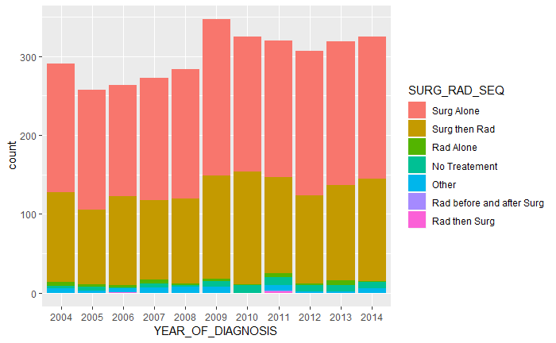

```r
data %>%
    ggplot(aes(x = YEAR_OF_DIAGNOSIS)) +
    geom_histogram(stat = "count", aes(fill = SURG_RAD_SEQ))
```

```
Ignoring unknown parameters: binwidth, bins, pad
```

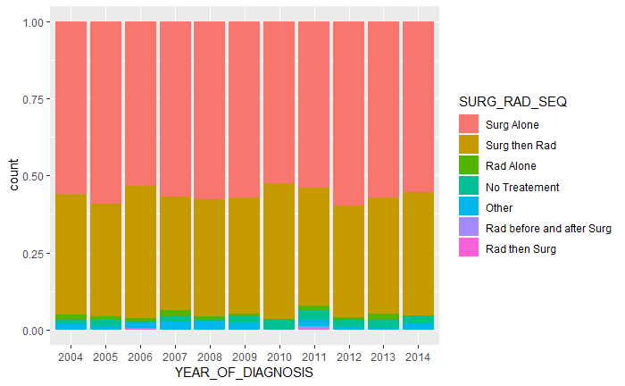

```r
data %>%
    ggplot(aes(x = YEAR_OF_DIAGNOSIS)) +
    geom_histogram(stat = "count", aes(fill = SURG_RAD_SEQ), position = "fill")
```

## Treatment by region

```r
p_table(data,
        vars = c("SURG_RAD_SEQ"),
        strata = c("FACILITY_LOCATION_F"))
```

|  | level | New England | Middle Atlantic | South Atlantic | East North Central | East South Central | West North Central | West South Central | Mountain | Pacific | p | test |
| --- | --- | --- | --- | --- | --- | --- | --- | --- | --- | --- | --- | --- |
| n |  | 145 | 351 | 490 | 500 | 146 | 218 | 152 | 128 | 315 |  |  |
| SURG_RAD_SEQ (%) | Surg Alone | 57 (39.3) | 168 (47.9) | 258 (52.7) | 262 (52.4) | 76 (52.1) | 115 (52.8) | 96 (63.2) | 70 (54.7) | 161 (51.1) | NaN |  |
|  | Surg then Rad | 79 (54.5) | 154 (43.9) | 208 (42.4) | 215 (43.0) | 65 (44.5) | 96 (44.0) | 43 (28.3) | 52 (40.6) | 137 (43.5) |  |  |
|  | Rad Alone | 5 ( 3.4) | 5 ( 1.4) | 6 ( 1.2) | 5 ( 1.0) | 1 ( 0.7) | 1 ( 0.5) | 1 ( 0.7) | 3 ( 2.3) | 7 ( 2.2) |  |  |
|  | No Treatement | 3 ( 2.1) | 10 ( 2.8) | 11 ( 2.2) | 10 ( 2.0) | 3 ( 2.1) | 4 ( 1.8) | 3 ( 2.0) | 1 ( 0.8) | 9 ( 2.9) |  |  |
|  | Other | 1 ( 0.7) | 13 ( 3.7) | 7 ( 1.4) | 7 ( 1.4) | 1 ( 0.7) | 2 ( 0.9) | 8 ( 5.3) | 2 ( 1.6) | 1 ( 0.3) |  |  |
|  | Rad before and after Surg | 0 ( 0.0) | 0 ( 0.0) | 0 ( 0.0) | 0 ( 0.0) | 0 ( 0.0) | 0 ( 0.0) | 0 ( 0.0) | 0 ( 0.0) | 0 ( 0.0) |  |  |
|  | Rad then Surg | 0 ( 0.0) | 1 ( 0.3) | 0 ( 0.0) | 1 ( 0.2) | 0 ( 0.0) | 0 ( 0.0) | 1 ( 0.7) | 0 ( 0.0) | 0 ( 0.0) |  |  |

## Demographics by region

```r
p_table(data,
        vars = c("AGE_F", "RACE_F", "SEX_F", "INCOME_F", "EDUCATION_F", "INSURANCE_F", "U_R_F"),
        strata = c("FACILITY_LOCATION_F"))
```

|  | level | New England | Middle Atlantic | South Atlantic | East North Central | East South Central | West North Central | West South Central | Mountain | Pacific | p | test |
| --- | --- | --- | --- | --- | --- | --- | --- | --- | --- | --- | --- | --- |
| n |  | 145 | 351 | 490 | 500 | 146 | 218 | 152 | 128 | 315 |  |  |
| AGE_F (%) | (0,54] | 46 (31.7) | 110 (31.3) | 166 (33.9) | 203 (40.6) | 54 (37.0) | 64 (29.4) | 55 (36.2) | 43 (33.6) | 135 (42.9) | 0.083 |  |
|  | (54,64] | 39 (26.9) | 105 (29.9) | 142 (29.0) | 128 (25.6) | 42 (28.8) | 69 (31.7) | 39 (25.7) | 29 (22.7) | 81 (25.7) |  |  |
|  | (64,74] | 27 (18.6) | 74 (21.1) | 102 (20.8) | 89 (17.8) | 32 (21.9) | 47 (21.6) | 35 (23.0) | 32 (25.0) | 64 (20.3) |  |  |
|  | (74,100] | 33 (22.8) | 62 (17.7) | 80 (16.3) | 80 (16.0) | 18 (12.3) | 38 (17.4) | 23 (15.1) | 24 (18.8) | 35 (11.1) |  |  |
| RACE_F (%) | White | 136 (93.8) | 301 (85.8) | 410 (83.7) | 451 (90.2) | 119 (81.5) | 208 (95.4) | 122 (80.3) | 122 (95.3) | 265 (84.1) | <0.001 |  |
|  | Black | 6 ( 4.1) | 29 ( 8.3) | 63 (12.9) | 37 ( 7.4) | 24 (16.4) | 5 ( 2.3) | 24 (15.8) | 2 ( 1.6) | 6 ( 1.9) |  |  |
|  | Other/Unk | 2 ( 1.4) | 11 ( 3.1) | 12 ( 2.4) | 8 ( 1.6) | 2 ( 1.4) | 4 ( 1.8) | 3 ( 2.0) | 3 ( 2.3) | 19 ( 6.0) |  |  |
|  | Asian | 1 ( 0.7) | 10 ( 2.8) | 5 ( 1.0) | 4 ( 0.8) | 1 ( 0.7) | 1 ( 0.5) | 3 ( 2.0) | 1 ( 0.8) | 25 ( 7.9) |  |  |
| SEX_F (%) | Male | 62 (42.8) | 140 (39.9) | 190 (38.8) | 189 (37.8) | 67 (45.9) | 81 (37.2) | 56 (36.8) | 62 (48.4) | 127 (40.3) | 0.338 |  |
|  | Female | 83 (57.2) | 211 (60.1) | 300 (61.2) | 311 (62.2) | 79 (54.1) | 137 (62.8) | 96 (63.2) | 66 (51.6) | 188 (59.7) |  |  |
| INCOME_F (%) | Less than $38,000 | 11 ( 7.6) | 41 (11.7) | 75 (15.3) | 48 ( 9.6) | 48 (32.9) | 18 ( 8.3) | 47 (30.9) | 16 (12.5) | 19 ( 6.0) | <0.001 |  |
|  | $38,000 - $47,999 | 10 ( 6.9) | 43 (12.3) | 124 (25.3) | 124 (24.8) | 38 (26.0) | 65 (29.8) | 39 (25.7) | 30 (23.4) | 47 (14.9) |  |  |
|  | $48,000 - $62,999 | 45 (31.0) | 86 (24.5) | 122 (24.9) | 156 (31.2) | 35 (24.0) | 56 (25.7) | 27 (17.8) | 44 (34.4) | 85 (27.0) |  |  |
|  | $63,000 + | 77 (53.1) | 177 (50.4) | 159 (32.4) | 169 (33.8) | 24 (16.4) | 78 (35.8) | 39 (25.7) | 37 (28.9) | 161 (51.1) |  |  |
|  | NA | 2 ( 1.4) | 4 ( 1.1) | 10 ( 2.0) | 3 ( 0.6) | 1 ( 0.7) | 1 ( 0.5) | 0 ( 0.0) | 1 ( 0.8) | 3 ( 1.0) |  |  |
| EDUCATION_F (%) | 21% or more | 9 ( 6.2) | 44 (12.5) | 69 (14.1) | 38 ( 7.6) | 36 (24.7) | 5 ( 2.3) | 59 (38.8) | 9 ( 7.0) | 49 (15.6) | <0.001 |  |
|  | 13 - 20.9% | 19 (13.1) | 59 (16.8) | 156 (31.8) | 107 (21.4) | 53 (36.3) | 36 (16.5) | 36 (23.7) | 23 (18.0) | 44 (14.0) |  |  |
|  | 7 - 12.9% | 63 (43.4) | 143 (40.7) | 153 (31.2) | 197 (39.4) | 37 (25.3) | 85 (39.0) | 32 (21.1) | 44 (34.4) | 115 (36.5) |  |  |
|  | Less than 7% | 52 (35.9) | 101 (28.8) | 103 (21.0) | 155 (31.0) | 20 (13.7) | 91 (41.7) | 25 (16.4) | 51 (39.8) | 104 (33.0) |  |  |
|  | NA | 2 ( 1.4) | 4 ( 1.1) | 9 ( 1.8) | 3 ( 0.6) | 0 ( 0.0) | 1 ( 0.5) | 0 ( 0.0) | 1 ( 0.8) | 3 ( 1.0) |  |  |
| INSURANCE_F (%) | Private | 77 (53.1) | 206 (58.7) | 275 (56.1) | 292 (58.4) | 80 (54.8) | 123 (56.4) | 77 (50.7) | 62 (48.4) | 185 (58.7) | 0.004 |  |
|  | None | 1 ( 0.7) | 8 ( 2.3) | 14 ( 2.9) | 10 ( 2.0) | 4 ( 2.7) | 2 ( 0.9) | 13 ( 8.6) | 5 ( 3.9) | 8 ( 2.5) |  |  |
|  | Medicaid | 3 ( 2.1) | 14 ( 4.0) | 13 ( 2.7) | 20 ( 4.0) | 8 ( 5.5) | 9 ( 4.1) | 5 ( 3.3) | 3 ( 2.3) | 19 ( 6.0) |  |  |
|  | Medicare | 61 (42.1) | 116 (33.0) | 175 (35.7) | 165 (33.0) | 49 (33.6) | 78 (35.8) | 52 (34.2) | 52 (40.6) | 90 (28.6) |  |  |
|  | Other Government | 2 ( 1.4) | 1 ( 0.3) | 6 ( 1.2) | 3 ( 0.6) | 3 ( 2.1) | 0 ( 0.0) | 2 ( 1.3) | 5 ( 3.9) | 5 ( 1.6) |  |  |
|  | Unknown | 1 ( 0.7) | 6 ( 1.7) | 7 ( 1.4) | 10 ( 2.0) | 2 ( 1.4) | 6 ( 2.8) | 3 ( 2.0) | 1 ( 0.8) | 8 ( 2.5) |  |  |
| U_R_F (%) | Metro | 119 (82.1) | 313 (89.2) | 413 (84.3) | 403 (80.6) | 111 (76.0) | 151 (69.3) | 128 (84.2) | 92 (71.9) | 272 (86.3) | <0.001 |  |
|  | Urban | 12 ( 8.3) | 29 ( 8.3) | 51 (10.4) | 85 (17.0) | 28 (19.2) | 48 (22.0) | 20 (13.2) | 26 (20.3) | 26 ( 8.3) |  |  |
|  | Rural | 1 ( 0.7) | 3 ( 0.9) | 6 ( 1.2) | 6 ( 1.2) | 6 ( 4.1) | 15 ( 6.9) | 1 ( 0.7) | 4 ( 3.1) | 3 ( 1.0) |  |  |
|  | NA | 13 ( 9.0) | 6 ( 1.7) | 20 ( 4.1) | 6 ( 1.2) | 1 ( 0.7) | 4 ( 1.8) | 3 ( 2.0) | 6 ( 4.7) | 14 ( 4.4) |  |  |

## Treatment by tumor size

```r
p_table(data,
        vars = c("SURG_RAD_SEQ"),
        strata = c("T_SIZE"))
```

|  | level | Microscopic focus | < 1 cm | 1-2 cm | 2-3 cm | 3-4 cm | 4-5 cm | 5-6 cm | >6 cm | NA_unk | p | test |
| --- | --- | --- | --- | --- | --- | --- | --- | --- | --- | --- | --- | --- |
| n |  | 3 | 182 | 1129 | 986 | 470 | 224 | 103 | 86 | 128 |  |  |
| SURG_RAD_SEQ (%) | Surg Alone | 3 (100.0) | 142 (78.0) | 733 (64.9) | 536 (54.4) | 221 (47.0) | 94 (42.0) | 33 (32.0) | 32 (37.2) | 67 (52.3) | <0.001 |  |
|  | Surg then Rad | 0 ( 0.0) | 34 (18.7) | 354 (31.4) | 419 (42.5) | 228 (48.5) | 118 (52.7) | 60 (58.3) | 44 (51.2) | 32 (25.0) |  |  |
|  | Rad Alone | 0 ( 0.0) | 0 ( 0.0) | 4 ( 0.4) | 7 ( 0.7) | 5 ( 1.1) | 4 ( 1.8) | 4 ( 3.9) | 5 ( 5.8) | 7 ( 5.5) |  |  |
|  | No Treatement | 0 ( 0.0) | 2 ( 1.1) | 18 ( 1.6) | 10 ( 1.0) | 11 ( 2.3) | 5 ( 2.2) | 3 ( 2.9) | 4 ( 4.7) | 14 (10.9) |  |  |
|  | Other | 0 ( 0.0) | 4 ( 2.2) | 19 ( 1.7) | 13 ( 1.3) | 4 ( 0.9) | 3 ( 1.3) | 2 ( 1.9) | 1 ( 1.2) | 8 ( 6.2) |  |  |
|  | Rad before and after Surg | 0 ( 0.0) | 0 ( 0.0) | 1 ( 0.1) | 0 ( 0.0) | 0 ( 0.0) | 0 ( 0.0) | 0 ( 0.0) | 0 ( 0.0) | 0 ( 0.0) |  |  |
|  | Rad then Surg | 0 ( 0.0) | 0 ( 0.0) | 0 ( 0.0) | 1 ( 0.1) | 1 ( 0.2) | 0 ( 0.0) | 1 ( 1.0) | 0 ( 0.0) | 0 ( 0.0) |  |  |

```
Ignoring unknown parameters: binwidth, bins, pad
```

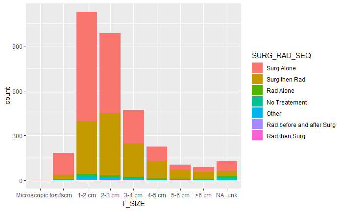

```r
data %>%
    ggplot(aes(x = T_SIZE)) +
    geom_histogram(stat = "count", aes(fill = SURG_RAD_SEQ))
```

```
Ignoring unknown parameters: binwidth, bins, pad
```

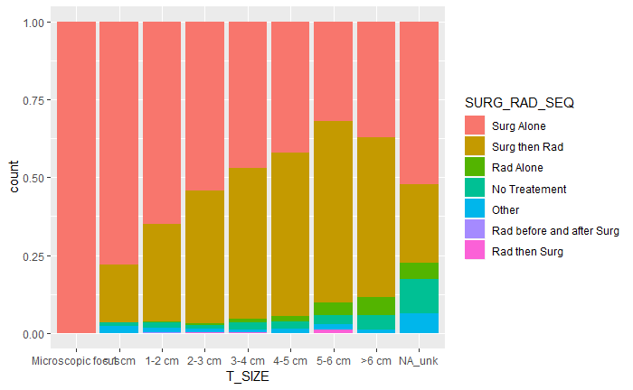

```r
data %>%
    ggplot(aes(x = T_SIZE)) +
    geom_histogram(stat = "count", aes(fill = SURG_RAD_SEQ), position = "fill")
```

# Tumor size by year

Limited to below 10 cm to exclude recording errors

```r
data <- data %>%
        mutate(TUMOR_SIZE_LIM = ifelse(TUMOR_SIZE < 100,
                                       TUMOR_SIZE,
                                        NA)) %>%
        mutate(T_SIZE_LIM = fct_recode(T_SIZE,
                                       NULL = "NA_unk"))
p_table(data,
        vars = c("TUMOR_SIZE", "TUMOR_SIZE_LIM", "T_SIZE_LIM"),
        strata = c("YEAR_OF_DIAGNOSIS"))
```

|  | level | 2004 | 2005 | 2006 | 2007 | 2008 | 2009 | 2010 | 2011 | 2012 | 2013 | 2014 | p | test |
| --- | --- | --- | --- | --- | --- | --- | --- | --- | --- | --- | --- | --- | --- | --- |
| n |  | 291 | 257 | 263 | 273 | 284 | 347 | 325 | 320 | 307 | 319 | 325 |  |  |
| TUMOR_SIZE (mean (sd)) |  | 107.11 (271.09) | 70.26 (206.77) | 78.01 (219.63) | 95.30 (254.37) | 75.38 (218.83) | 65.69 (198.76) | 80.25 (229.14) | 97.80 (256.82) | 62.48 (188.76) | 71.03 (206.42) | 67.70 (198.39) | 0.228 |  |
| TUMOR_SIZE_LIM (mean (sd)) |  | 24.06 (14.42) | 23.02 (12.41) | 25.03 (13.04) | 24.01 (13.59) | 23.55 (13.44) | 23.58 (12.46) | 23.32 (12.56) | 24.20 (13.38) | 24.55 (12.67) | 25.03 (14.13) | 24.94 (13.13) | 0.632 |  |
| T_SIZE_LIM (%) | Microscopic focus | 1 ( 0.3) | 0 ( 0.0) | 0 ( 0.0) | 1 ( 0.4) | 0 ( 0.0) | 0 ( 0.0) | 0 ( 0.0) | 0 ( 0.0) | 0 ( 0.0) | 1 ( 0.3) | 0 ( 0.0) | 0.041 |  |
|  | < 1 cm | 13 ( 4.5) | 19 ( 7.4) | 14 ( 5.3) | 12 ( 4.4) | 18 ( 6.3) | 19 ( 5.5) | 16 ( 4.9) | 18 ( 5.6) | 18 ( 5.9) | 23 ( 7.2) | 12 ( 3.7) |  |  |
|  | 1-2 cm | 103 (35.4) | 85 (33.1) | 76 (28.9) | 95 (34.8) | 101 (35.6) | 127 (36.6) | 116 (35.7) | 105 (32.8) | 95 (30.9) | 108 (33.9) | 118 (36.3) |  |  |
|  | 2-3 cm | 80 (27.5) | 85 (33.1) | 95 (36.1) | 88 (32.2) | 76 (26.8) | 93 (26.8) | 106 (32.6) | 104 (32.5) | 109 (35.5) | 74 (23.2) | 76 (23.4) |  |  |
|  | 3-4 cm | 42 (14.4) | 31 (12.1) | 28 (10.6) | 32 (11.7) | 42 (14.8) | 57 (16.4) | 40 (12.3) | 37 (11.6) | 46 (15.0) | 52 (16.3) | 63 (19.4) |  |  |
|  | 4-5 cm | 13 ( 4.5) | 11 ( 4.3) | 22 ( 8.4) | 14 ( 5.1) | 17 ( 6.0) | 25 ( 7.2) | 18 ( 5.5) | 19 ( 5.9) | 21 ( 6.8) | 34 (10.7) | 30 ( 9.2) |  |  |
|  | 5-6 cm | 10 ( 3.4) | 10 ( 3.9) | 12 ( 4.6) | 8 ( 2.9) | 10 ( 3.5) | 11 ( 3.2) | 7 ( 2.2) | 11 ( 3.4) | 9 ( 2.9) | 8 ( 2.5) | 7 ( 2.2) |  |  |
|  | >6 cm | 12 ( 4.1) | 8 ( 3.1) | 6 ( 2.3) | 8 ( 2.9) | 6 ( 2.1) | 3 ( 0.9) | 9 ( 2.8) | 11 ( 3.4) | 5 ( 1.6) | 10 ( 3.1) | 8 ( 2.5) |  |  |
|  | NA | 17 ( 5.8) | 8 ( 3.1) | 10 ( 3.8) | 15 ( 5.5) | 14 ( 4.9) | 12 ( 3.5) | 13 ( 4.0) | 15 ( 4.7) | 4 ( 1.3) | 9 ( 2.8) | 11 ( 3.4) |  |  |

```r
data %>%
        mutate(YEAR = as.numeric(as.character(YEAR_OF_DIAGNOSIS))) %>%
        lm(TUMOR_SIZE_LIM ~ YEAR,
              data = .) %>%
        summary()
```

```
Call:
lm(formula = TUMOR_SIZE_LIM ~ YEAR, data = .)

Residuals:
    Min      1Q  Median      3Q     Max
-23.524  -9.102  -3.471   5.793  71.425

Coefficients:
             Estimate Std. Error t value Pr(>|t|)
(Intercept) -187.7089   151.6996  -1.237    0.216
YEAR           0.1054     0.0755   1.396    0.163

Residual standard error: 13.2 on 3114 degrees of freedom
  (195 observations deleted due to missingness)
Multiple R-squared:  0.0006258, Adjusted R-squared:  0.0003049
F-statistic:  1.95 on 1 and 3114 DF,  p-value: 0.1627
```

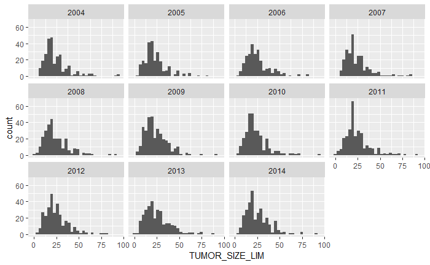

```r
data %>%
    ggplot(aes(x = TUMOR_SIZE_LIM)) +
    geom_histogram() +
    facet_wrap(~ YEAR_OF_DIAGNOSIS)
```

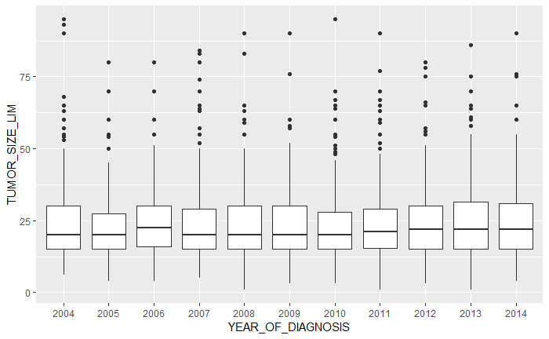

```r
data %>%
    ggplot(aes(x = YEAR_OF_DIAGNOSIS, y = TUMOR_SIZE_LIM)) +
    geom_boxplot()
```

```
Ignoring unknown parameters: binwidth, bins, pad
```

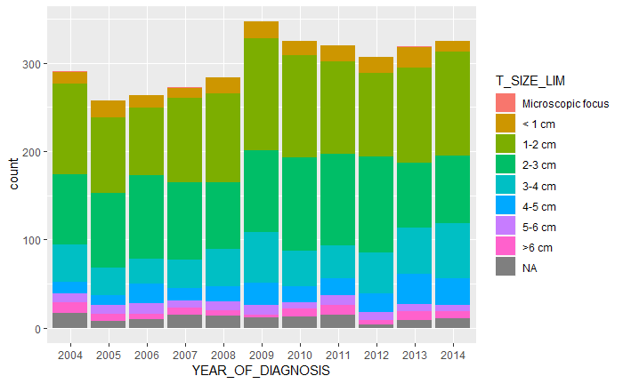

```r
data %>%
        ggplot(aes(x = YEAR_OF_DIAGNOSIS)) +
        geom_histogram(stat = "count",
                       aes(fill = T_SIZE_LIM))
```

```
Ignoring unknown parameters: binwidth, bins, pad
```

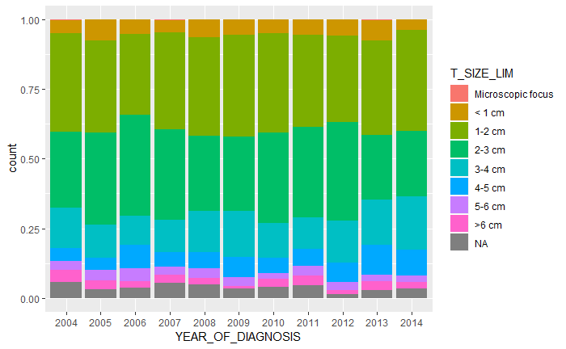

```r
data %>%
        ggplot(aes(x = YEAR_OF_DIAGNOSIS)) +
        geom_histogram(stat = "count",
                       aes(fill = T_SIZE_LIM),
                       position = "fill")
```

# Treatment models

```r
data <- data %>%
        mutate(FACILITY_LOCATION_F = fct_relevel(FACILITY_LOCATION_F,
                                             "New England")) %>%
        mutate(SURG_TX = case_when(SURGERY_YN == "Yes" ~ TRUE,
                                   SURGERY_YN == "No" ~ FALSE,
                                   TRUE ~ NA)) %>%
        mutate(YEAR_OF_DIAGNOSIS = fct_relevel(YEAR_OF_DIAGNOSIS,
                                               "2014"))
fit_surg <- glm(SURG_TX ~ AGE + SEX + CDCC_TOTAL + T_SIZE + FACILITY_TYPE_F + FACILITY_LOCATION_F +
                        YEAR_OF_DIAGNOSIS,
                family = "binomial",
                data = data)
summary(fit_surg)
```

```
Call:
glm(formula = SURG_TX ~ AGE + SEX + CDCC_TOTAL + T_SIZE + FACILITY_TYPE_F +
    FACILITY_LOCATION_F + YEAR_OF_DIAGNOSIS, family = "binomial",
    data = data)

Deviance Residuals:
    Min       1Q   Median       3Q      Max
-3.0963   0.1197   0.1784   0.2644   1.2662

Coefficients:
                                               Estimate Std. Error z value Pr(>|z|)
(Intercept)                                   1.886e+01  1.383e+03   0.014   0.9891
AGE                                          -5.599e-02  9.334e-03  -5.999 1.99e-09 ***
SEX2                                          5.691e-01  2.331e-01   2.441   0.0146 *
CDCC_TOTAL1                                   5.355e-01  3.939e-01   1.359   0.1740
CDCC_TOTAL2                                  -6.579e-01  5.395e-01  -1.219   0.2227
CDCC_TOTAL3                                   1.373e+01  6.563e+02   0.021   0.9833
T_SIZE< 1 cm                                 -1.141e+01  1.383e+03  -0.008   0.9934
T_SIZE1-2 cm                                 -1.230e+01  1.383e+03  -0.009   0.9929
T_SIZE2-3 cm                                 -1.221e+01  1.383e+03  -0.009   0.9930
T_SIZE3-4 cm                                 -1.286e+01  1.383e+03  -0.009   0.9926
T_SIZE4-5 cm                                 -1.301e+01  1.383e+03  -0.009   0.9925
T_SIZE5-6 cm                                 -1.369e+01  1.383e+03  -0.010   0.9921
T_SIZE>6 cm                                  -1.390e+01  1.383e+03  -0.010   0.9920
T_SIZENA_unk                                 -1.462e+01  1.383e+03  -0.011   0.9916
FACILITY_TYPE_FComprehensive Comm Ca Program  2.356e-01  3.929e-01   0.600   0.5488
FACILITY_TYPE_FAcademic/Research Program      6.215e-01  3.962e-01   1.569   0.1167
FACILITY_TYPE_FIntegrated Network Ca Program  3.604e-01  5.074e-01   0.710   0.4775
FACILITY_LOCATION_FMiddle Atlantic            1.308e-01  4.805e-01   0.272   0.7854
FACILITY_LOCATION_FSouth Atlantic             5.670e-01  4.856e-01   1.168   0.2429
FACILITY_LOCATION_FEast North Central         5.685e-01  4.878e-01   1.165   0.2438
FACILITY_LOCATION_FEast South Central         8.884e-01  6.686e-01   1.329   0.1839
FACILITY_LOCATION_FWest North Central         7.901e-01  6.135e-01   1.288   0.1978
FACILITY_LOCATION_FWest South Central         6.220e-01  6.573e-01   0.946   0.3439
FACILITY_LOCATION_FMountain                   6.962e-01  6.693e-01   1.040   0.2983
FACILITY_LOCATION_FPacific                   -1.145e-01  4.839e-01  -0.237   0.8130
YEAR_OF_DIAGNOSIS2004                        -1.114e-01  5.544e-01  -0.201   0.8408
YEAR_OF_DIAGNOSIS2005                        -4.143e-01  5.635e-01  -0.735   0.4622
YEAR_OF_DIAGNOSIS2006                         3.125e-01  6.622e-01   0.472   0.6370
YEAR_OF_DIAGNOSIS2007                        -4.968e-01  5.447e-01  -0.912   0.3617
YEAR_OF_DIAGNOSIS2008                         5.100e-01  6.610e-01   0.771   0.4404
YEAR_OF_DIAGNOSIS2009                        -1.746e-01  5.362e-01  -0.326   0.7447
YEAR_OF_DIAGNOSIS2010                        -4.756e-02  5.541e-01  -0.086   0.9316
YEAR_OF_DIAGNOSIS2011                        -7.484e-01  5.118e-01  -1.462   0.1437
YEAR_OF_DIAGNOSIS2012                        -2.509e-01  5.728e-01  -0.438   0.6613
YEAR_OF_DIAGNOSIS2013                        -7.151e-01  5.012e-01  -1.427   0.1537
---
Signif. codes:  0 *** 0.001 ** 0.01 * 0.05 . 0.1   1

(Dispersion parameter for binomial family taken to be 1)

    Null deviance: 763.94  on 2437  degrees of freedom
Residual deviance: 628.36  on 2403  degrees of freedom
  (873 observations deleted due to missingness)
AIC: 698.36

Number of Fisher Scoring iterations: 15
```

```r
exp(cbind("Odds ratio" = coef(fit_surg), confint.default(fit_surg, level = 0.95)))
```

```
                                               Odds ratio     2.5 %    97.5 %
(Intercept)                                  1.552354e+08 0.0000000       Inf
AGE                                          9.455452e-01 0.9284036 0.9630034
SEX2                                         1.766614e+00 1.1186558 2.7898895
CDCC_TOTAL1                                  1.708293e+00 0.7893464 3.6970644
CDCC_TOTAL2                                  5.179555e-01 0.1799161 1.4911276
CDCC_TOTAL3                                  9.175958e+05 0.0000000       Inf
T_SIZE< 1 cm                                 1.105759e-05 0.0000000       Inf
T_SIZE1-2 cm                                 4.573992e-06 0.0000000       Inf
T_SIZE2-3 cm                                 4.983770e-06 0.0000000       Inf
T_SIZE3-4 cm                                 2.604830e-06 0.0000000       Inf
T_SIZE4-5 cm                                 2.240372e-06 0.0000000       Inf
T_SIZE5-6 cm                                 1.136497e-06 0.0000000       Inf
T_SIZE>6 cm                                  9.217009e-07 0.0000000       Inf
T_SIZENA_unk                                 4.453170e-07 0.0000000       Inf
FACILITY_TYPE_FComprehensive Comm Ca Program 1.265615e+00 0.5860032 2.7334011
FACILITY_TYPE_FAcademic/Research Program     1.861628e+00 0.8564108 4.0467237
FACILITY_TYPE_FIntegrated Network Ca Program 1.433913e+00 0.5304307 3.8762981
FACILITY_LOCATION_FMiddle Atlantic           1.139781e+00 0.4444627 2.9228590
FACILITY_LOCATION_FSouth Atlantic            1.762994e+00 0.6806602 4.5663699
FACILITY_LOCATION_FEast North Central        1.765617e+00 0.6786953 4.5932292
FACILITY_LOCATION_FEast South Central        2.431331e+00 0.6557931 9.0140784
FACILITY_LOCATION_FWest North Central        2.203601e+00 0.6620599 7.3344656
FACILITY_LOCATION_FWest South Central        1.862737e+00 0.5136839 6.7547154
FACILITY_LOCATION_FMountain                  2.006042e+00 0.5402993 7.4481047
FACILITY_LOCATION_FPacific                   8.918157e-01 0.3454366 2.3024063
YEAR_OF_DIAGNOSIS2004                        8.946201e-01 0.3018383 2.6515695
YEAR_OF_DIAGNOSIS2005                        6.608202e-01 0.2189951 1.9940326
YEAR_OF_DIAGNOSIS2006                        1.366799e+00 0.3733075 5.0042896
YEAR_OF_DIAGNOSIS2007                        6.084700e-01 0.2092153 1.7696399
YEAR_OF_DIAGNOSIS2008                        1.665256e+00 0.4558257 6.0836337
YEAR_OF_DIAGNOSIS2009                        8.397955e-01 0.2936238 2.4019054
YEAR_OF_DIAGNOSIS2010                        9.535560e-01 0.3218858 2.8248191
YEAR_OF_DIAGNOSIS2011                        4.731115e-01 0.1734965 1.2901385
YEAR_OF_DIAGNOSIS2012                        7.780739e-01 0.2531922 2.3910648
YEAR_OF_DIAGNOSIS2013                        4.891610e-01 0.1831517 1.3064494
```

# Kaplan Meier Analysis

```r
uni_var <- function(test_var, data_imp) {

        cat("_________________________________________________")
        cat("\n")
        cat("   \n##", test_var)
        cat("\n")
        cat("_________________________________________________")
        cat("\n")

        f <- as.formula(paste("Surv(DX_LASTCONTACT_DEATH_MONTHS, PUF_VITAL_STATUS == 0)",
                              as.name(test_var),
                              sep = " ~ " ))

        data_imp_2 <- deparse(substitute(data_imp))
        km_fit <- do.call("survfit", list(formula = f, data = as.name(data_imp_2)))
        print(km_fit)
        cat("\n")
        print(summary(km_fit, times = c(12, 24, 36, 48, 60, 120)))
        cat("\n")
        cat("\n")
        cat("\n")
        cat("   \n## Univariable Cox Proportional Hazard Model for: ", test_var)
        cat("\n")
        cat("\n")
        n_levels <- nlevels(data_imp[[test_var]])
        if(n_levels == 1){
                print("Only one level, no Cox model performed")
                cat("\n")
        } else {
                cox_fit <- do.call("coxph", list(formula = f, data = as.name(data_imp_2)))
                print(summary(cox_fit))
                cat("\n")

                do.call("ggforest",
                         list(model = cox_fit, data = as.name(data_imp_2)))
        }
        cat("\n")
        cat("\n")
        cat("\n")
        cat("   \n## Unadjusted Kaplan Meier Overall Survival Curve for: ", test_var)
        p <- do.call("ggsurvplot",
                     list(fit = km_fit, data = as.name(data_imp_2),
                          palette = "jco", censor = FALSE, legend = "right",
                          linetype = "strata", xlab = "Time (Months)"))
        print(p)
}
```

## All

```r
uni_var(test_var = "All", data_imp = data)
```

[output not shown]

```
_________________________________________________

## All
_________________________________________________
Call: survfit(formula = Surv(DX_LASTCONTACT_DEATH_MONTHS, PUF_VITAL_STATUS ==
    0) ~ All, data = data)

      n  events  median 0.95LCL 0.95UCL
   3311     440      NA     152      NA

Call: survfit(formula = Surv(DX_LASTCONTACT_DEATH_MONTHS, PUF_VITAL_STATUS ==
    0) ~ All, data = data)

 time n.risk n.event survival std.err lower 95% CI upper 95% CI
   12   3112      59    0.982 0.00237        0.977        0.986
   24   2765      78    0.956 0.00368        0.949        0.963
   36   2339      88    0.924 0.00492        0.914        0.933
   48   1966      51    0.902 0.00565        0.891        0.913
   60   1595      47    0.879 0.00646        0.866        0.891
  120    322     111    0.772 0.01185        0.749        0.796




## Univariable Cox Proportional Hazard Model for:  All

[1] "Only one level, no Cox model performed"





## Unadjusted Kaplan Meier Overall Survival Curve for:  All
```

## Facility Type

```
_________________________________________________

## FACILITY_TYPE_F
_________________________________________________
Call: survfit(formula = Surv(DX_LASTCONTACT_DEATH_MONTHS, PUF_VITAL_STATUS ==
    0) ~ FACILITY_TYPE_F, data = data)

   866 observations deleted due to missingness
                                                 n events median 0.95LCL 0.95UCL
FACILITY_TYPE_F=Community Cancer Program       204     44    152     124      NA
FACILITY_TYPE_F=Comprehensive Comm Ca Program  923    160     NA     146      NA
FACILITY_TYPE_F=Academic/Research Program     1040    170     NA      NA      NA
FACILITY_TYPE_F=Integrated Network Ca Program  278     45     NA      NA      NA

Call: survfit(formula = Surv(DX_LASTCONTACT_DEATH_MONTHS, PUF_VITAL_STATUS ==
    0) ~ FACILITY_TYPE_F, data = data)

866 observations deleted due to missingness
                FACILITY_TYPE_F=Community Cancer Program
 time n.risk n.event survival std.err lower 95% CI upper 95% CI
   12    193       6    0.970  0.0120        0.947        0.994
   24    171       9    0.923  0.0191        0.886        0.961
   36    148       4    0.900  0.0218        0.858        0.944
   48    127       3    0.880  0.0242        0.834        0.929
   60     95       8    0.818  0.0309        0.759        0.881
  120     17      12    0.642  0.0568        0.540        0.764

                FACILITY_TYPE_F=Comprehensive Comm Ca Program
 time n.risk n.event survival std.err lower 95% CI upper 95% CI
   12    869      24    0.973 0.00534        0.963        0.984
   24    776      24    0.946 0.00764        0.931        0.961
   36    640      37    0.897 0.01064        0.876        0.918
   48    547      22    0.864 0.01234        0.840        0.889
   60    442      17    0.835 0.01381        0.808        0.863
  120     86      34    0.716 0.02376        0.671        0.764

                FACILITY_TYPE_F=Academic/Research Program
 time n.risk n.event survival std.err lower 95% CI upper 95% CI
   12    976      24    0.976 0.00479        0.967        0.986
   24    848      37    0.938 0.00774        0.923        0.953
```

[output cut: 27 more lines]

```
                                                coef exp(coef) se(coef)      z Pr(>|z|)
FACILITY_TYPE_FComprehensive Comm Ca Program -0.2189    0.8034   0.1705 -1.283    0.199
FACILITY_TYPE_FAcademic/Research Program     -0.2582    0.7724   0.1693 -1.525    0.127
FACILITY_TYPE_FIntegrated Network Ca Program -0.2905    0.7479   0.2122 -1.369    0.171

                                             exp(coef) exp(-coef) lower .95 upper .95
FACILITY_TYPE_FComprehensive Comm Ca Program    0.8034      1.245    0.5752     1.122
FACILITY_TYPE_FAcademic/Research Program        0.7724      1.295    0.5543     1.076
FACILITY_TYPE_FIntegrated Network Ca Program    0.7479      1.337    0.4934     1.134

Concordance= 0.513  (se = 0.014 )
Rsquare= 0.001   (max possible= 0.916 )
Likelihood ratio test= 2.46  on 3 df,   p=0.5
Wald test            = 2.6  on 3 df,   p=0.5
Score (logrank) test = 2.61  on 3 df,   p=0.5
```

```
Removed 1 rows containing missing values (geom_errorbar).
```

```
## Unadjusted Kaplan Meier Overall Survival Curve for:  FACILITY_TYPE_F
```

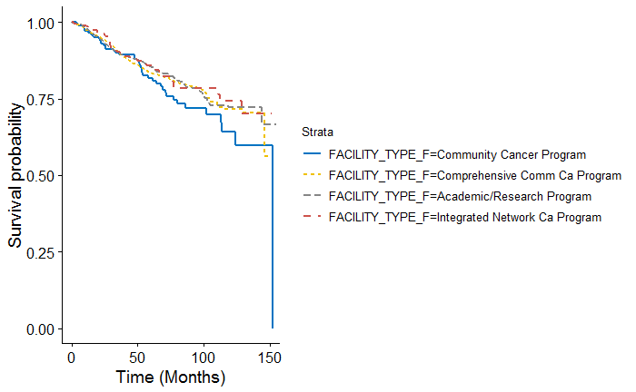

```r
uni_var(test_var = "FACILITY_TYPE_F", data_imp = data)
```

## Facility Location

```
_________________________________________________

## FACILITY_LOCATION_F
_________________________________________________
Call: survfit(formula = Surv(DX_LASTCONTACT_DEATH_MONTHS, PUF_VITAL_STATUS ==
    0) ~ FACILITY_LOCATION_F, data = data)

   866 observations deleted due to missingness
                                         n events median 0.95LCL 0.95UCL
FACILITY_LOCATION_F=New England        145     31     NA      NA      NA
FACILITY_LOCATION_F=Middle Atlantic    351     58     NA      NA      NA
FACILITY_LOCATION_F=South Atlantic     490     84     NA     144      NA
FACILITY_LOCATION_F=East North Central 500     91    152     152      NA
FACILITY_LOCATION_F=East South Central 146     27     NA      NA      NA
FACILITY_LOCATION_F=West North Central 218     41     NA      NA      NA
FACILITY_LOCATION_F=West South Central 152     17     NA      NA      NA
FACILITY_LOCATION_F=Mountain           128     24     NA      NA      NA
FACILITY_LOCATION_F=Pacific            315     46     NA     146      NA

Call: survfit(formula = Surv(DX_LASTCONTACT_DEATH_MONTHS, PUF_VITAL_STATUS ==
    0) ~ FACILITY_LOCATION_F, data = data)

866 observations deleted due to missingness
                FACILITY_LOCATION_F=New England
 time n.risk n.event survival std.err lower 95% CI upper 95% CI
   12    139       2    0.986 0.00989        0.967        1.000
   24    121       8    0.927 0.02218        0.885        0.972
   36     99      10    0.847 0.03170        0.787        0.911
   48     86       3    0.819 0.03440        0.754        0.889
   60     75       1    0.809 0.03534        0.743        0.882
  120     19       7    0.667 0.05863        0.562        0.793

                FACILITY_LOCATION_F=Middle Atlantic
 time n.risk n.event survival std.err lower 95% CI upper 95% CI
   12    330      10    0.971 0.00903        0.953        0.989
   24    284      10    0.941 0.01284        0.916        0.966
   36    246      10    0.905 0.01654        0.874        0.938
   48    210       8    0.874 0.01933        0.837        0.913
   60    166       5    0.851 0.02150        0.809        0.894
  120     28      14    0.720 0.04066        0.645        0.805
```

[output cut: 89 more lines]

```
                                      exp(coef) exp(-coef) lower .95 upper .95
FACILITY_LOCATION_FMiddle Atlantic       0.8361      1.196    0.5405     1.293
FACILITY_LOCATION_FSouth Atlantic        0.8262      1.210    0.5472     1.247
FACILITY_LOCATION_FEast North Central    0.8843      1.131    0.5881     1.330
FACILITY_LOCATION_FEast South Central    0.9988      1.001    0.5960     1.674
FACILITY_LOCATION_FWest North Central    0.9075      1.102    0.5690     1.447
FACILITY_LOCATION_FWest South Central    0.5822      1.718    0.3222     1.052
FACILITY_LOCATION_FMountain              0.9925      1.008    0.5824     1.691
FACILITY_LOCATION_FPacific               0.7159      1.397    0.4540     1.129

Concordance= 0.534  (se = 0.015 )
Rsquare= 0.003   (max possible= 0.916 )
Likelihood ratio test= 6.58  on 8 df,   p=0.6
Wald test            = 6.28  on 8 df,   p=0.6
Score (logrank) test = 6.34  on 8 df,   p=0.6
```

```
Removed 1 rows containing missing values (geom_errorbar).
```

```
## Unadjusted Kaplan Meier Overall Survival Curve for:  FACILITY_LOCATION_F
```

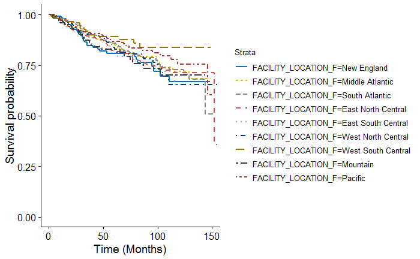

```r
uni_var(test_var = "FACILITY_LOCATION_F", data_imp = data)
```

## Facility Geography

```
_________________________________________________

## FACILITY_GEOGRAPHY
_________________________________________________
Call: survfit(formula = Surv(DX_LASTCONTACT_DEATH_MONTHS, PUF_VITAL_STATUS ==
    0) ~ FACILITY_GEOGRAPHY, data = data)

   866 observations deleted due to missingness
                               n events median 0.95LCL 0.95UCL
FACILITY_GEOGRAPHY=Northeast 496     89     NA      NA      NA
FACILITY_GEOGRAPHY=South     642    101     NA     144      NA
FACILITY_GEOGRAPHY=Midwest   864    159    152     152      NA
FACILITY_GEOGRAPHY=West      443     70     NA     146      NA

Call: survfit(formula = Surv(DX_LASTCONTACT_DEATH_MONTHS, PUF_VITAL_STATUS ==
    0) ~ FACILITY_GEOGRAPHY, data = data)

866 observations deleted due to missingness
                FACILITY_GEOGRAPHY=Northeast
 time n.risk n.event survival std.err lower 95% CI upper 95% CI
   12    469      12    0.975 0.00702        0.962        0.989
   24    405      18    0.937 0.01118        0.915        0.959
   36    345      20    0.888 0.01506        0.859        0.918
   48    296      11    0.858 0.01707        0.825        0.892
   60    241       6    0.838 0.01840        0.803        0.875
  120     47      21    0.704 0.03330        0.641        0.772

                FACILITY_GEOGRAPHY=South
 time n.risk n.event survival std.err lower 95% CI upper 95% CI
   12    605      13    0.979 0.00570        0.968        0.990
   24    553      11    0.961 0.00783        0.946        0.976
   36    466      26    0.913 0.01177        0.890        0.937
   48    396      13    0.886 0.01359        0.860        0.913
   60    319       9    0.865 0.01506        0.836        0.895
  120     49      26    0.747 0.02701        0.696        0.802

                FACILITY_GEOGRAPHY=Midwest
 time n.risk n.event survival std.err lower 95% CI upper 95% CI
   12    819      16    0.981 0.00469        0.972        0.990
   24    717      32    0.941 0.00826        0.925        0.957
```

[output cut: 27 more lines]

```
                              coef exp(coef) se(coef)      z Pr(>|z|)
FACILITY_GEOGRAPHYSouth   -0.13883   0.87038  0.14540 -0.955    0.340
FACILITY_GEOGRAPHYMidwest  0.02377   1.02405  0.13255  0.179    0.858
FACILITY_GEOGRAPHYWest    -0.11355   0.89266  0.15977 -0.711    0.477

                          exp(coef) exp(-coef) lower .95 upper .95
FACILITY_GEOGRAPHYSouth      0.8704     1.1489    0.6545     1.157
FACILITY_GEOGRAPHYMidwest    1.0241     0.9765    0.7898     1.328
FACILITY_GEOGRAPHYWest       0.8927     1.1203    0.6527     1.221

Concordance= 0.52  (se = 0.015 )
Rsquare= 0.001   (max possible= 0.916 )
Likelihood ratio test= 2.16  on 3 df,   p=0.5
Wald test            = 2.14  on 3 df,   p=0.5
Score (logrank) test = 2.15  on 3 df,   p=0.5
```

```
Removed 1 rows containing missing values (geom_errorbar).
```

```
## Unadjusted Kaplan Meier Overall Survival Curve for:  FACILITY_GEOGRAPHY
```

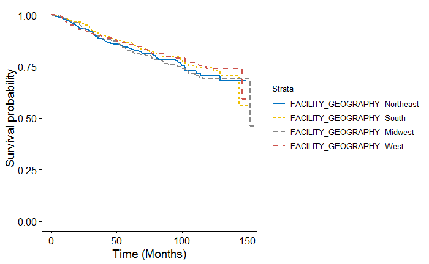

```r
uni_var(test_var = "FACILITY_GEOGRAPHY", data_imp = data)
```

## Age Group

```
_________________________________________________

## AGE_F
_________________________________________________
Call: survfit(formula = Surv(DX_LASTCONTACT_DEATH_MONTHS, PUF_VITAL_STATUS ==
    0) ~ AGE_F, data = data)

                  n events median 0.95LCL 0.95UCL
AGE_F=(0,54]   1742     95     NA      NA      NA
AGE_F=(54,64]   674     84     NA      NA      NA
AGE_F=(64,74]   502     92     NA      NA      NA
AGE_F=(74,100]  393    169   81.3    72.8     102

Call: survfit(formula = Surv(DX_LASTCONTACT_DEATH_MONTHS, PUF_VITAL_STATUS ==
    0) ~ AGE_F, data = data)

                AGE_F=(0,54]
 time n.risk n.event survival std.err lower 95% CI upper 95% CI
   12   1650       6    0.996 0.00146        0.994        0.999
   24   1493      19    0.984 0.00308        0.978        0.991
   36   1291      18    0.972 0.00420        0.964        0.980
   48   1088      15    0.960 0.00518        0.950        0.970
   60    897      11    0.950 0.00600        0.938        0.961
  120    203      25    0.908 0.01051        0.887        0.929

                AGE_F=(54,64]
 time n.risk n.event survival std.err lower 95% CI upper 95% CI
   12    639      13    0.980 0.00542        0.970        0.991
   24    563      14    0.958 0.00792        0.943        0.974
   36    484      18    0.925 0.01076        0.905        0.947
   48    414       6    0.914 0.01165        0.891        0.937
   60    328      11    0.887 0.01387        0.860        0.914
  120     65      20    0.781 0.02758        0.729        0.837

                AGE_F=(64,74]
 time n.risk n.event survival std.err lower 95% CI upper 95% CI
   12    461      15    0.969 0.00791        0.954        0.985
   24    416      15    0.936 0.01129        0.914        0.959
   36    330      19    0.889 0.01499        0.861        0.919
   48    275      13    0.852 0.01762        0.818        0.887
```

[output cut: 26 more lines]

```
AGE_F(64,74]   1.3255    3.7639   0.1464  9.054  < 2e-16 ***
AGE_F(74,100]  2.3217   10.1932   0.1287 18.047  < 2e-16 ***
---
Signif. codes:  0 *** 0.001 ** 0.01 * 0.05 . 0.1   1

              exp(coef) exp(-coef) lower .95 upper .95
AGE_F(54,64]      2.374     0.4212     1.770     3.184
AGE_F(64,74]      3.764     0.2657     2.825     5.015
AGE_F(74,100]    10.193     0.0981     7.921    13.117

Concordance= 0.72  (se = 0.013 )
Rsquare= 0.098   (max possible= 0.865 )
Likelihood ratio test= 342.3  on 3 df,   p=<2e-16
Wald test            = 349.7  on 3 df,   p=<2e-16
Score (logrank) test = 474.6  on 3 df,   p=<2e-16
```

```
Removed 1 rows containing missing values (geom_errorbar).
```

```
## Unadjusted Kaplan Meier Overall Survival Curve for:  AGE_F
```

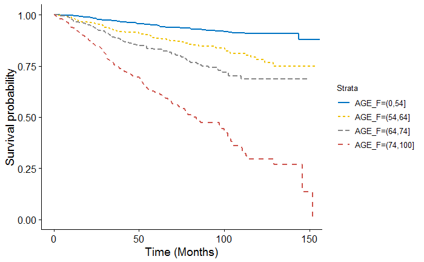

```r
uni_var(test_var = "AGE_F", data_imp = data)
```

## Age Group

```
_________________________________________________

## AGE_40
_________________________________________________
Call: survfit(formula = Surv(DX_LASTCONTACT_DEATH_MONTHS, PUF_VITAL_STATUS ==
    0) ~ AGE_40, data = data)

                   n events median 0.95LCL 0.95UCL
AGE_40=(0,40]    914     23     NA      NA      NA
AGE_40=(40,100] 2397    417    152     152      NA

Call: survfit(formula = Surv(DX_LASTCONTACT_DEATH_MONTHS, PUF_VITAL_STATUS ==
    0) ~ AGE_40, data = data)

                AGE_40=(0,40]
 time n.risk n.event survival std.err lower 95% CI upper 95% CI
   12    861       1    0.999 0.00115        0.997        1.000
   24    777       2    0.996 0.00208        0.992        1.000
   36    661       4    0.991 0.00345        0.984        0.998
   48    544       5    0.983 0.00502        0.973        0.993
   60    453       1    0.981 0.00534        0.970        0.991
  120    106      10    0.943 0.01347        0.917        0.970

                AGE_40=(40,100]
 time n.risk n.event survival std.err lower 95% CI upper 95% CI
   12   2251      58    0.975 0.00322        0.969        0.982
   24   1988      76    0.941 0.00495        0.931        0.951
   36   1678      84    0.899 0.00652        0.886        0.912
   48   1422      46    0.873 0.00739        0.858        0.887
   60   1142      46    0.842 0.00841        0.826        0.859
  120    216     101    0.712 0.01500        0.683        0.742





## Univariable Cox Proportional Hazard Model for:  AGE_40

Call:
coxph(formula = Surv(DX_LASTCONTACT_DEATH_MONTHS, PUF_VITAL_STATUS ==
    0) ~ AGE_40, data = data)

  n= 3311, number of events= 440

                 coef exp(coef) se(coef)     z Pr(>|z|)
AGE_40(40,100] 1.9800    7.2425   0.2143 9.239   <2e-16 ***
---
Signif. codes:  0 *** 0.001 ** 0.01 * 0.05 . 0.1   1

               exp(coef) exp(-coef) lower .95 upper .95
AGE_40(40,100]     7.242     0.1381     4.759     11.02

Concordance= 0.618  (se = 0.011 )
Rsquare= 0.046   (max possible= 0.865 )
Likelihood ratio test= 157.1  on 1 df,   p=<2e-16
Wald test            = 85.37  on 1 df,   p=<2e-16
Score (logrank) test = 117  on 1 df,   p=<2e-16
```

```
Removed 1 rows containing missing values (geom_errorbar).
```

```
## Unadjusted Kaplan Meier Overall Survival Curve for:  AGE_40
```

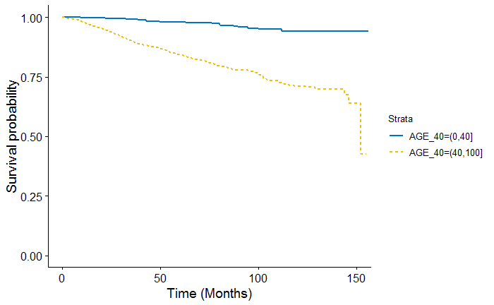

```r
uni_var(test_var = "AGE_40", data_imp = data)
```

## Gender

```
_________________________________________________

## SEX_F
_________________________________________________
Call: survfit(formula = Surv(DX_LASTCONTACT_DEATH_MONTHS, PUF_VITAL_STATUS ==
    0) ~ SEX_F, data = data)

                n events median 0.95LCL 0.95UCL
SEX_F=Male   1276    207     NA      NA      NA
SEX_F=Female 2035    233     NA     152      NA

Call: survfit(formula = Surv(DX_LASTCONTACT_DEATH_MONTHS, PUF_VITAL_STATUS ==
    0) ~ SEX_F, data = data)

                SEX_F=Male
 time n.risk n.event survival std.err lower 95% CI upper 95% CI
   12   1192      28    0.977 0.00423        0.969        0.986
   24   1057      33    0.949 0.00635        0.937        0.962
   36    882      47    0.904 0.00881        0.887        0.922
   48    735      26    0.876 0.01015        0.856        0.896
   60    593      21    0.849 0.01143        0.827        0.871
  120     98      51    0.718 0.02155        0.677        0.762

                SEX_F=Female
 time n.risk n.event survival std.err lower 95% CI upper 95% CI
   12   1920      31    0.984 0.00280        0.979        0.990
   24   1708      45    0.960 0.00447        0.952        0.969
   36   1457      41    0.936 0.00577        0.925        0.947
   48   1231      25    0.919 0.00661        0.906        0.932
   60   1002      26    0.897 0.00766        0.882        0.913
  120    224      60    0.804 0.01403        0.777        0.832





## Univariable Cox Proportional Hazard Model for:  SEX_F

Call:
coxph(formula = Surv(DX_LASTCONTACT_DEATH_MONTHS, PUF_VITAL_STATUS ==
    0) ~ SEX_F, data = data)

  n= 3311, number of events= 440

                coef exp(coef) se(coef)      z Pr(>|z|)
SEX_FFemale -0.40986   0.66374  0.09559 -4.288 1.81e-05 ***
---
Signif. codes:  0 *** 0.001 ** 0.01 * 0.05 . 0.1   1

            exp(coef) exp(-coef) lower .95 upper .95
SEX_FFemale    0.6637      1.507    0.5503    0.8005

Concordance= 0.551  (se = 0.012 )
Rsquare= 0.005   (max possible= 0.865 )
Likelihood ratio test= 18.11  on 1 df,   p=2e-05
Wald test            = 18.38  on 1 df,   p=2e-05
Score (logrank) test = 18.64  on 1 df,   p=2e-05
```

```
Removed 1 rows containing missing values (geom_errorbar).
```

```
## Unadjusted Kaplan Meier Overall Survival Curve for:  SEX_F
```

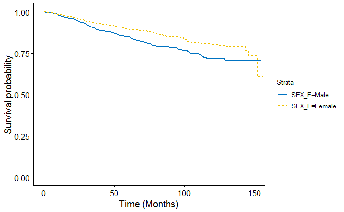

```r
uni_var(test_var = "SEX_F", data_imp = data)
```

## RACE_F

```
_________________________________________________

## RACE_F
_________________________________________________
Call: survfit(formula = Surv(DX_LASTCONTACT_DEATH_MONTHS, PUF_VITAL_STATUS ==
    0) ~ RACE_F, data = data)

                    n events median 0.95LCL 0.95UCL
RACE_F=White     2798    404     NA     152      NA
RACE_F=Black      320     21     NA      NA      NA
RACE_F=Other/Unk  106     14     NA      NA      NA
RACE_F=Asian       87      1     NA      NA      NA

Call: survfit(formula = Surv(DX_LASTCONTACT_DEATH_MONTHS, PUF_VITAL_STATUS ==
    0) ~ RACE_F, data = data)

                RACE_F=White
 time n.risk n.event survival std.err lower 95% CI upper 95% CI
   12   2628      55    0.980 0.00271        0.974        0.985
   24   2339      71    0.952 0.00416        0.944        0.960
   36   1970      80    0.918 0.00553        0.907        0.928
   48   1661      46    0.895 0.00633        0.882        0.907
   60   1346      44    0.869 0.00725        0.855        0.883
  120    273     102    0.754 0.01321        0.729        0.780

                RACE_F=Black
 time n.risk n.event survival std.err lower 95% CI upper 95% CI
   12    298       4    0.987 0.00639        0.975        1.000
   24    265       2    0.980 0.00810        0.964        0.996
   36    229       6    0.956 0.01235        0.933        0.981
   48    192       2    0.947 0.01392        0.920        0.975
   60    159       1    0.942 0.01481        0.913        0.971
  120     28       6    0.893 0.02436        0.846        0.942

                RACE_F=Other/Unk
 time n.risk n.event survival std.err lower 95% CI upper 95% CI
   12    101       0    1.000  0.0000        1.000        1.000
   24     85       5    0.948  0.0225        0.905        0.994
   36     77       1    0.937  0.0249        0.890        0.987
   48     66       3    0.898  0.0324        0.837        0.964
```

[output cut: 26 more lines]

```
RACE_FOther/Unk -0.09553   0.90889  0.27190 -0.351 0.725339
RACE_FAsian     -2.48639   0.08321  1.00132 -2.483 0.013024 *
---
Signif. codes:  0 *** 0.001 ** 0.01 * 0.05 . 0.1   1

                exp(coef) exp(-coef) lower .95 upper .95
RACE_FBlack       0.45804      2.183   0.29538    0.7103
RACE_FOther/Unk   0.90889      1.100   0.53343    1.5486
RACE_FAsian       0.08321     12.018   0.01169    0.5922

Concordance= 0.537  (se = 0.009 )
Rsquare= 0.009   (max possible= 0.865 )
Likelihood ratio test= 31.09  on 3 df,   p=8e-07
Wald test            = 18.18  on 3 df,   p=4e-04
Score (logrank) test = 22.54  on 3 df,   p=5e-05
```

```
Removed 1 rows containing missing values (geom_errorbar).
```

```
## Unadjusted Kaplan Meier Overall Survival Curve for:  RACE_F
```

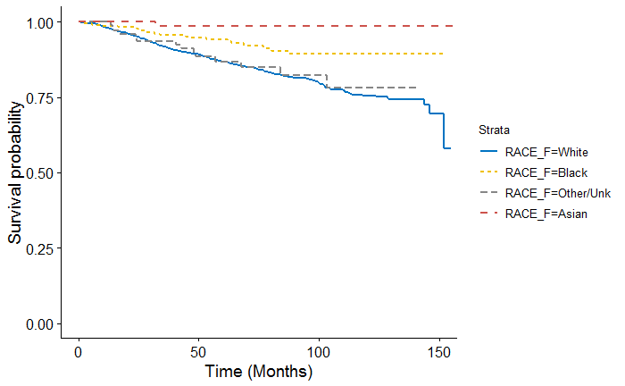

```r
uni_var(test_var = "RACE_F", data_imp = data)
```

## Hispanic

```
_________________________________________________

## HISPANIC
_________________________________________________
Call: survfit(formula = Surv(DX_LASTCONTACT_DEATH_MONTHS, PUF_VITAL_STATUS ==
    0) ~ HISPANIC, data = data)

                    n events median 0.95LCL 0.95UCL
HISPANIC=No      2922    387     NA     152      NA
HISPANIC=Yes      186     14     NA      NA      NA
HISPANIC=Unknown  203     39     NA      NA      NA

Call: survfit(formula = Surv(DX_LASTCONTACT_DEATH_MONTHS, PUF_VITAL_STATUS ==
    0) ~ HISPANIC, data = data)

                HISPANIC=No
 time n.risk n.event survival std.err lower 95% CI upper 95% CI
   12   2756      54    0.981 0.00256        0.976        0.986
   24   2441      71    0.955 0.00397        0.947        0.962
   36   2062      76    0.923 0.00525        0.913        0.933
   48   1728      42    0.903 0.00599        0.891        0.915
   60   1402      38    0.881 0.00680        0.868        0.895
  120    279     100    0.772 0.01265        0.748        0.798

                HISPANIC=Yes
 time n.risk n.event survival std.err lower 95% CI upper 95% CI
   12    166       3    0.982  0.0100        0.963        1.000
   24    146       1    0.976  0.0117        0.954        1.000
   36    119       4    0.948  0.0181        0.913        0.984
   48    100       4    0.914  0.0242        0.868        0.962
   60     77       1    0.903  0.0260        0.854        0.956
  120     13       1    0.880  0.0341        0.816        0.950

                HISPANIC=Unknown
 time n.risk n.event survival std.err lower 95% CI upper 95% CI
   12    190       2    0.990 0.00723        0.976        1.000
   24    178       6    0.958 0.01447        0.930        0.987
   36    158       8    0.914 0.02063        0.874        0.955
   48    138       5    0.884 0.02395        0.838        0.932
   60    116       8    0.830 0.02900        0.775        0.889
```

[output cut: 12 more lines]

```
  n= 3311, number of events= 440

                   coef exp(coef) se(coef)      z Pr(>|z|)
HISPANICYes     -0.4432    0.6420   0.2721 -1.629    0.103
HISPANICUnknown  0.2534    1.2884   0.1681  1.507    0.132

                exp(coef) exp(-coef) lower .95 upper .95
HISPANICYes         0.642     1.5577    0.3766     1.094
HISPANICUnknown     1.288     0.7761    0.9267     1.791

Concordance= 0.516  (se = 0.008 )
Rsquare= 0.002   (max possible= 0.865 )
Likelihood ratio test= 5.5  on 2 df,   p=0.06
Wald test            = 5.22  on 2 df,   p=0.07
Score (logrank) test = 5.29  on 2 df,   p=0.07
```

```
Removed 1 rows containing missing values (geom_errorbar).
```

```
## Unadjusted Kaplan Meier Overall Survival Curve for:  HISPANIC
```

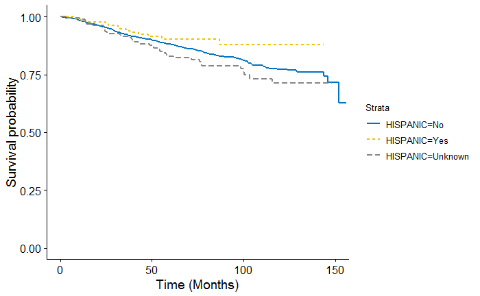

```r
uni_var(test_var = "HISPANIC", data_imp = data)
```

## Insurance Status

```
_________________________________________________

## INSURANCE_F
_________________________________________________
Call: survfit(formula = Surv(DX_LASTCONTACT_DEATH_MONTHS, PUF_VITAL_STATUS ==
    0) ~ INSURANCE_F, data = data)

                                n events median 0.95LCL 0.95UCL
INSURANCE_F=Private          2053    158     NA      NA      NA
INSURANCE_F=None              115     12     NA      NA      NA
INSURANCE_F=Medicaid          188     15     NA      NA      NA
INSURANCE_F=Medicare          854    245    146     113      NA
INSURANCE_F=Other Government   42      5     NA      NA      NA
INSURANCE_F=Unknown            59      5     NA      NA      NA

Call: survfit(formula = Surv(DX_LASTCONTACT_DEATH_MONTHS, PUF_VITAL_STATUS ==
    0) ~ INSURANCE_F, data = data)

                INSURANCE_F=Private
 time n.risk n.event survival std.err lower 95% CI upper 95% CI
   12   1950      21    0.989 0.00229        0.985        0.994
   24   1766      25    0.976 0.00345        0.970        0.983
   36   1521      32    0.958 0.00470        0.949        0.967
   48   1290      18    0.946 0.00543        0.935        0.956
   60   1056      19    0.931 0.00636        0.918        0.943
  120    233      40    0.871 0.01175        0.848        0.894

                INSURANCE_F=None
 time n.risk n.event survival std.err lower 95% CI upper 95% CI
   12    105       0    1.000 0.00000        1.000        1.000
   24     93       1    0.990 0.00985        0.971        1.000
   36     78       5    0.934 0.02632        0.883        0.987
   48     60       3    0.894 0.03370        0.830        0.963
   60     44       1    0.879 0.03637        0.810        0.953
  120      7       2    0.795 0.06554        0.676        0.934

                INSURANCE_F=Medicaid
 time n.risk n.event survival std.err lower 95% CI upper 95% CI
   12    174       2    0.989 0.00799        0.973        1.000
   24    145       3    0.970 0.01314        0.945        0.996
```

[output cut: 50 more lines]

```
---
Signif. codes:  0 *** 0.001 ** 0.01 * 0.05 . 0.1   1

                            exp(coef) exp(-coef) lower .95 upper .95
INSURANCE_FNone                 1.606     0.6227    0.8926     2.889
INSURANCE_FMedicaid             1.250     0.8002    0.7357     2.123
INSURANCE_FMedicare             4.261     0.2347    3.4876     5.205
INSURANCE_FOther Government     1.818     0.5500    0.7464     4.430
INSURANCE_FUnknown              1.260     0.7936    0.5173     3.070

Concordance= 0.665  (se = 0.013 )
Rsquare= 0.061   (max possible= 0.865 )
Likelihood ratio test= 209  on 5 df,   p=<2e-16
Wald test            = 211.5  on 5 df,   p=<2e-16
Score (logrank) test = 248.8  on 5 df,   p=<2e-16
```

```
Removed 1 rows containing missing values (geom_errorbar).
```

```
## Unadjusted Kaplan Meier Overall Survival Curve for:  INSURANCE_F
```

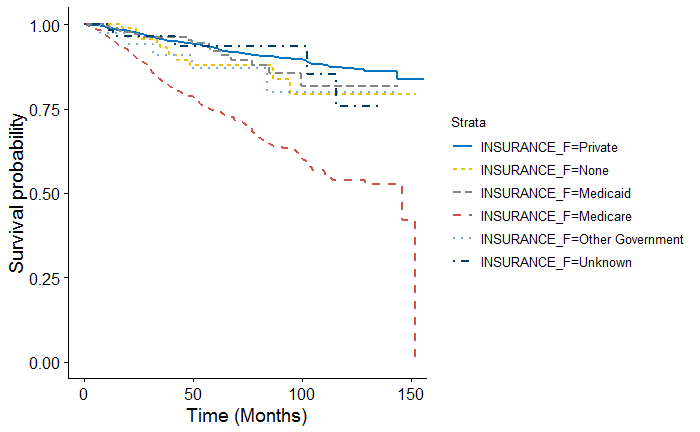

```r
uni_var(test_var = "INSURANCE_F", data_imp = data)
```

## Income

```
_________________________________________________

## INCOME_F
_________________________________________________
Call: survfit(formula = Surv(DX_LASTCONTACT_DEATH_MONTHS, PUF_VITAL_STATUS ==
    0) ~ INCOME_F, data = data)

   31 observations deleted due to missingness
                              n events median 0.95LCL 0.95UCL
INCOME_F=Less than $38,000  469     64     NA     144      NA
INCOME_F=$38,000 - $47,999  700     92     NA      NA      NA
INCOME_F=$48,000 - $62,999  878    134    152     146      NA
INCOME_F=$63,000 +         1233    144     NA      NA      NA

Call: survfit(formula = Surv(DX_LASTCONTACT_DEATH_MONTHS, PUF_VITAL_STATUS ==
    0) ~ INCOME_F, data = data)

31 observations deleted due to missingness
                INCOME_F=Less than $38,000
 time n.risk n.event survival std.err lower 95% CI upper 95% CI
   12    434       9    0.980 0.00659        0.967        0.993
   24    384       9    0.959 0.00953        0.940        0.978
   36    322      12    0.926 0.01302        0.901        0.952
   48    269      11    0.893 0.01604        0.862        0.925
   60    218       4    0.878 0.01735        0.845        0.913
  120     35      18    0.763 0.03120        0.704        0.826

                INCOME_F=$38,000 - $47,999
 time n.risk n.event survival std.err lower 95% CI upper 95% CI
   12    655      10    0.985 0.00465        0.976        0.994
   24    587      14    0.963 0.00733        0.949        0.978
   36    495      16    0.935 0.00994        0.916        0.955
   48    413       9    0.917 0.01140        0.895        0.940
   60    328      13    0.885 0.01407        0.858        0.913
  120     63      30    0.747 0.02834        0.693        0.804

                INCOME_F=$48,000 - $62,999
 time n.risk n.event survival std.err lower 95% CI upper 95% CI
   12    825      16    0.981 0.00466        0.972        0.990
   24    734      19    0.958 0.00699        0.944        0.972
```

[output cut: 27 more lines]

```
                              coef exp(coef) se(coef)      z Pr(>|z|)
INCOME_F$38,000 - $47,999 -0.06866   0.93365  0.16278 -0.422    0.673
INCOME_F$48,000 - $62,999  0.04868   1.04988  0.15199  0.320    0.749
INCOME_F$63,000 +         -0.22648   0.79734  0.15027 -1.507    0.132

                          exp(coef) exp(-coef) lower .95 upper .95
INCOME_F$38,000 - $47,999    0.9336     1.0711    0.6786     1.285
INCOME_F$48,000 - $62,999    1.0499     0.9525    0.7794     1.414
INCOME_F$63,000 +            0.7973     1.2542    0.5939     1.070

Concordance= 0.518  (se = 0.014 )
Rsquare= 0.002   (max possible= 0.864 )
Likelihood ratio test= 5.78  on 3 df,   p=0.1
Wald test            = 5.71  on 3 df,   p=0.1
Score (logrank) test = 5.74  on 3 df,   p=0.1
```

```
Removed 1 rows containing missing values (geom_errorbar).
```

```
## Unadjusted Kaplan Meier Overall Survival Curve for:  INCOME_F
```

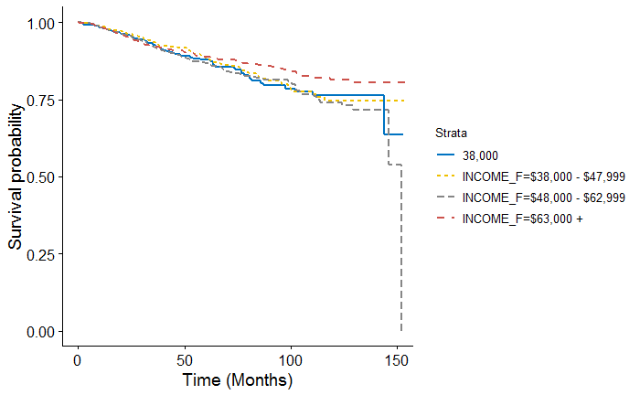

```r
uni_var(test_var = "INCOME_F", data_imp = data)
```

## Education

```
_________________________________________________

## EDUCATION_F
_________________________________________________
Call: survfit(formula = Surv(DX_LASTCONTACT_DEATH_MONTHS, PUF_VITAL_STATUS ==
    0) ~ EDUCATION_F, data = data)

   29 observations deleted due to missingness
                            n events median 0.95LCL 0.95UCL
EDUCATION_F=21% or more   460     45     NA     144      NA
EDUCATION_F=13 - 20.9%    732     99    152      NA      NA
EDUCATION_F=7 - 12.9%    1140    179     NA      NA      NA
EDUCATION_F=Less than 7%  950    111     NA      NA      NA

Call: survfit(formula = Surv(DX_LASTCONTACT_DEATH_MONTHS, PUF_VITAL_STATUS ==
    0) ~ EDUCATION_F, data = data)

29 observations deleted due to missingness
                EDUCATION_F=21% or more
 time n.risk n.event survival std.err lower 95% CI upper 95% CI
   12    428       7    0.984 0.00591        0.973        0.996
   24    379       9    0.963 0.00916        0.945        0.981
   36    320       9    0.938 0.01209        0.915        0.962
   48    254       9    0.908 0.01529        0.879        0.938
   60    205       4    0.892 0.01698        0.859        0.926
  120     36       6    0.842 0.02633        0.792        0.895

                EDUCATION_F=13 - 20.9%
 time n.risk n.event survival std.err lower 95% CI upper 95% CI
   12    689       9    0.987 0.00423        0.979        0.996
   24    617      14    0.966 0.00690        0.953        0.980
   36    532      15    0.941 0.00932        0.923        0.959
   48    446      12    0.918 0.01116        0.897        0.941
   60    360      12    0.891 0.01327        0.866        0.918
  120     59      35    0.720 0.03174        0.660        0.785

                EDUCATION_F=7 - 12.9%
 time n.risk n.event survival std.err lower 95% CI upper 95% CI
   12   1068      23    0.979 0.00430        0.971        0.988
   24    950      31    0.950 0.00668        0.937        0.963
```

[output cut: 29 more lines]

```
EDUCATION_F7 - 12.9%    0.4258    1.5307   0.1668 2.553   0.0107 *
EDUCATION_FLess than 7% 0.1010    1.1063   0.1768 0.571   0.5678
---
Signif. codes:  0 *** 0.001 ** 0.01 * 0.05 . 0.1   1

                        exp(coef) exp(-coef) lower .95 upper .95
EDUCATION_F13 - 20.9%       1.323     0.7558    0.9301     1.882
EDUCATION_F7 - 12.9%        1.531     0.6533    1.1039     2.123
EDUCATION_FLess than 7%     1.106     0.9039    0.7823     1.564

Concordance= 0.535  (se = 0.014 )
Rsquare= 0.003   (max possible= 0.864 )
Likelihood ratio test= 10.95  on 3 df,   p=0.01
Wald test            = 10.79  on 3 df,   p=0.01
Score (logrank) test = 10.89  on 3 df,   p=0.01
```

```
Removed 1 rows containing missing values (geom_errorbar).
```

```
## Unadjusted Kaplan Meier Overall Survival Curve for:  EDUCATION_F
```

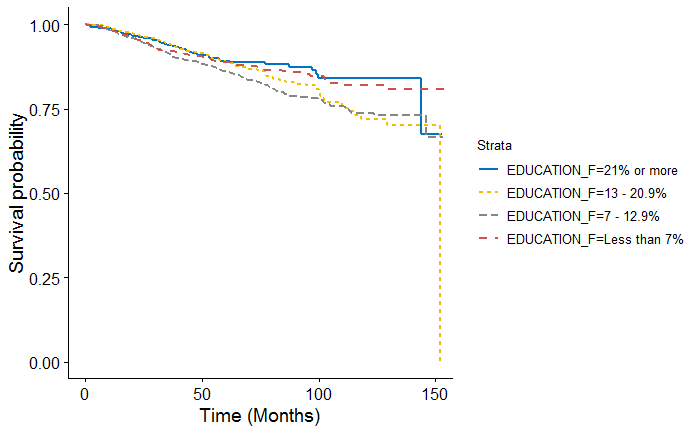

```r
uni_var(test_var = "EDUCATION_F", data_imp = data)
```

## Urban/Rural

```
_________________________________________________

## U_R_F
_________________________________________________
Call: survfit(formula = Surv(DX_LASTCONTACT_DEATH_MONTHS, PUF_VITAL_STATUS ==
    0) ~ U_R_F, data = data)

   97 observations deleted due to missingness
               n events median 0.95LCL 0.95UCL
U_R_F=Metro 2730    348     NA      NA      NA
U_R_F=Urban  426     59    152     152      NA
U_R_F=Rural   58     16    129     129      NA

Call: survfit(formula = Surv(DX_LASTCONTACT_DEATH_MONTHS, PUF_VITAL_STATUS ==
    0) ~ U_R_F, data = data)

97 observations deleted due to missingness
                U_R_F=Metro
 time n.risk n.event survival std.err lower 95% CI upper 95% CI
   12   2579      47    0.982 0.00256        0.977        0.987
   24   2295      61    0.958 0.00395        0.950        0.966
   36   1951      74    0.925 0.00536        0.915        0.936
   48   1630      41    0.904 0.00615        0.892        0.916
   60   1337      33    0.884 0.00692        0.871        0.898
  120    265      88    0.782 0.01275        0.758        0.808

                U_R_F=Urban
 time n.risk n.event survival std.err lower 95% CI upper 95% CI
   12    392       8    0.980  0.0069        0.967        0.994
   24    346      13    0.947  0.0113        0.925        0.969
   36    282       6    0.929  0.0132        0.904        0.955
   48    246       8    0.902  0.0160        0.871        0.934
   60    195       7    0.873  0.0189        0.837        0.911
  120     39      16    0.757  0.0333        0.695        0.825

                U_R_F=Rural
 time n.risk n.event survival std.err lower 95% CI upper 95% CI
   12     53       2    0.964  0.0252        0.915        1.000
   24     44       4    0.889  0.0429        0.808        0.977
   36     37       4    0.804  0.0559        0.702        0.922
```

[output cut: 17 more lines]

```
             coef exp(coef) se(coef)     z Pr(>|z|)
U_R_FUrban 0.1217    1.1294   0.1408 0.864 0.387384
U_R_FRural 0.8987    2.4565   0.2557 3.514 0.000441 ***
---
Signif. codes:  0 *** 0.001 ** 0.01 * 0.05 . 0.1   1

           exp(coef) exp(-coef) lower .95 upper .95
U_R_FUrban     1.129     0.8854     0.857     1.488
U_R_FRural     2.456     0.4071     1.488     4.055

Concordance= 0.517  (se = 0.009 )
Rsquare= 0.003   (max possible= 0.862 )
Likelihood ratio test= 9.98  on 2 df,   p=0.007
Wald test            = 12.69  on 2 df,   p=0.002
Score (logrank) test = 13.5  on 2 df,   p=0.001
```

```
Removed 1 rows containing missing values (geom_errorbar).
```

```
## Unadjusted Kaplan Meier Overall Survival Curve for:  U_R_F
```

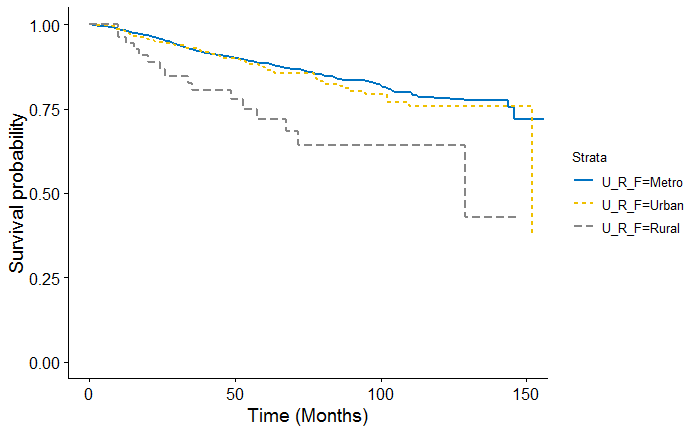

```r
uni_var(test_var = "U_R_F", data_imp = data)
```

## Comorbidities

```
_________________________________________________

## CDCC_TOTAL
_________________________________________________
Call: survfit(formula = Surv(DX_LASTCONTACT_DEATH_MONTHS, PUF_VITAL_STATUS ==
    0) ~ CDCC_TOTAL, data = data)

                n events median 0.95LCL 0.95UCL
CDCC_TOTAL=0 2878    352     NA   152.0      NA
CDCC_TOTAL=1  363     64     NA      NA      NA
CDCC_TOTAL=2   56     17     NA    68.9      NA
CDCC_TOTAL=3   14      7   57.1    38.2      NA

Call: survfit(formula = Surv(DX_LASTCONTACT_DEATH_MONTHS, PUF_VITAL_STATUS ==
    0) ~ CDCC_TOTAL, data = data)

                CDCC_TOTAL=0
 time n.risk n.event survival std.err lower 95% CI upper 95% CI
   12   2717      41    0.985 0.00228        0.981        0.990
   24   2418      62    0.962 0.00369        0.955        0.969
   36   2059      72    0.931 0.00502        0.922        0.941
   48   1729      44    0.910 0.00584        0.899        0.922
   60   1409      37    0.889 0.00666        0.876        0.902
  120    289      90    0.791 0.01220        0.767        0.815

                CDCC_TOTAL=1
 time n.risk n.event survival std.err lower 95% CI upper 95% CI
   12    334      14    0.960  0.0104        0.940        0.981
   24    295      12    0.925  0.0142        0.897        0.953
   36    240      11    0.887  0.0177        0.853        0.922
   48    209       4    0.871  0.0190        0.835        0.909
   60    163       7    0.839  0.0218        0.797        0.883
  120     28      16    0.672  0.0460        0.587        0.768

                CDCC_TOTAL=2
 time n.risk n.event survival std.err lower 95% CI upper 95% CI
   12     49       2    0.962  0.0265        0.911        1.000
   24     40       4    0.880  0.0462        0.794        0.975
   36     31       4    0.789  0.0596        0.681        0.915
   48     22       2    0.730  0.0683        0.608        0.877
```

[output cut: 26 more lines]

```
CDCC_TOTAL2 1.1794    3.2524   0.2485 4.746 2.08e-06 ***
CDCC_TOTAL3 1.6751    5.3392   0.3820 4.385 1.16e-05 ***
---
Signif. codes:  0 *** 0.001 ** 0.01 * 0.05 . 0.1   1

            exp(coef) exp(-coef) lower .95 upper .95
CDCC_TOTAL1     1.552     0.6444     1.189     2.026
CDCC_TOTAL2     3.252     0.3075     1.998     5.294
CDCC_TOTAL3     5.339     0.1873     2.525    11.288

Concordance= 0.545  (se = 0.008 )
Rsquare= 0.011   (max possible= 0.865 )
Likelihood ratio test= 35.38  on 3 df,   p=1e-07
Wald test            = 47.35  on 3 df,   p=3e-10
Score (logrank) test = 54.08  on 3 df,   p=1e-11
```

```
Removed 1 rows containing missing values (geom_errorbar).
```

```
## Unadjusted Kaplan Meier Overall Survival Curve for:  CDCC_TOTAL
```

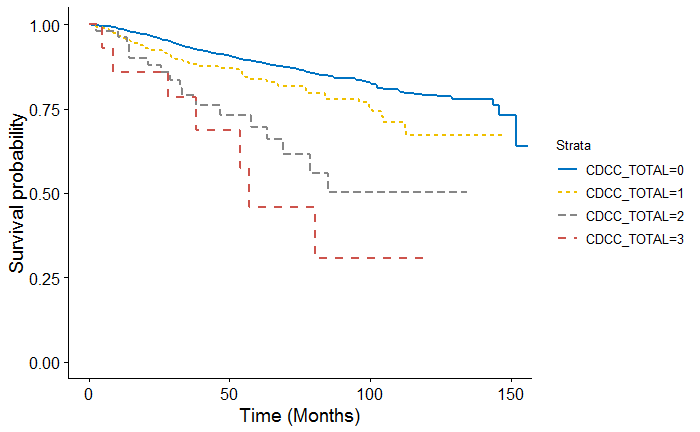

```r
uni_var(test_var = "CDCC_TOTAL", data_imp = data)
```

## Class (treatment at performing facility)

```
_________________________________________________

## CLASS_OF_CASE_F
_________________________________________________
Call: survfit(formula = Surv(DX_LASTCONTACT_DEATH_MONTHS, PUF_VITAL_STATUS ==
    0) ~ CLASS_OF_CASE_F, data = data)

                                  n events median 0.95LCL 0.95UCL
CLASS_OF_CASE_F=Other_Facility   69     19     NA    50.5      NA
CLASS_OF_CASE_F=All_Part_Prim  3242    421     NA   152.0      NA

Call: survfit(formula = Surv(DX_LASTCONTACT_DEATH_MONTHS, PUF_VITAL_STATUS ==
    0) ~ CLASS_OF_CASE_F, data = data)

                CLASS_OF_CASE_F=Other_Facility
 time n.risk n.event survival std.err lower 95% CI upper 95% CI
   12     49       3    0.946  0.0305        0.888        1.000
   24     39       5    0.843  0.0512        0.749        0.950
   36     32       3    0.779  0.0594        0.670        0.904
   48     24       3    0.698  0.0691        0.575        0.847
   60     17       3    0.607  0.0775        0.473        0.780
  120      2       2    0.509  0.0909        0.359        0.723

                CLASS_OF_CASE_F=All_Part_Prim
 time n.risk n.event survival std.err lower 95% CI upper 95% CI
   12   3063      56    0.982 0.00235        0.978        0.987
   24   2726      73    0.958 0.00363        0.951        0.965
   36   2307      85    0.926 0.00489        0.917        0.936
   48   1942      48    0.905 0.00561        0.895        0.917
   60   1578      44    0.883 0.00641        0.871        0.896
  120    320     109    0.777 0.01189        0.754        0.800





## Univariable Cox Proportional Hazard Model for:  CLASS_OF_CASE_F

Call:
coxph(formula = Surv(DX_LASTCONTACT_DEATH_MONTHS, PUF_VITAL_STATUS ==
    0) ~ CLASS_OF_CASE_F, data = data)

  n= 3311, number of events= 440

                                coef exp(coef) se(coef)    z Pr(>|z|)
CLASS_OF_CASE_FAll_Part_Prim -1.2925    0.2746   0.2350 -5.5 3.79e-08 ***
---
Signif. codes:  0 *** 0.001 ** 0.01 * 0.05 . 0.1   1

                             exp(coef) exp(-coef) lower .95 upper .95
CLASS_OF_CASE_FAll_Part_Prim    0.2746      3.642    0.1732    0.4352

Concordance= 0.518  (se = 0.003 )
Rsquare= 0.006   (max possible= 0.865 )
Likelihood ratio test= 21.07  on 1 df,   p=4e-06
Wald test            = 30.26  on 1 df,   p=4e-08
Score (logrank) test = 34.71  on 1 df,   p=4e-09
```

```
Removed 1 rows containing missing values (geom_errorbar).
```

```
## Unadjusted Kaplan Meier Overall Survival Curve for:  CLASS_OF_CASE_F
```

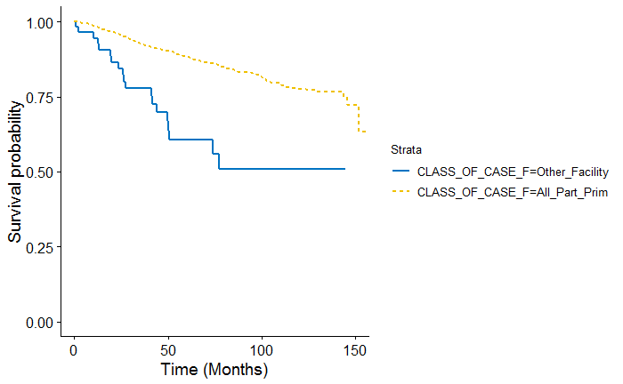

```r
uni_var(test_var = "CLASS_OF_CASE_F", data_imp = data)
```

## Year

```
_________________________________________________

## YEAR_OF_DIAGNOSIS
_________________________________________________
Call: survfit(formula = Surv(DX_LASTCONTACT_DEATH_MONTHS, PUF_VITAL_STATUS ==
    0) ~ YEAR_OF_DIAGNOSIS, data = data)

                         n events median 0.95LCL 0.95UCL
YEAR_OF_DIAGNOSIS=2014 325     11     NA      NA      NA
YEAR_OF_DIAGNOSIS=2004 291     66     NA   152.0      NA
YEAR_OF_DIAGNOSIS=2005 257     42     NA      NA      NA
YEAR_OF_DIAGNOSIS=2006 263     63     NA      NA      NA
YEAR_OF_DIAGNOSIS=2007 273     53     NA      NA      NA
YEAR_OF_DIAGNOSIS=2008 284     34     NA      NA      NA
YEAR_OF_DIAGNOSIS=2009 347     47     NA      NA      NA
YEAR_OF_DIAGNOSIS=2010 325     37     NA      NA      NA
YEAR_OF_DIAGNOSIS=2011 320     31     NA      NA      NA
YEAR_OF_DIAGNOSIS=2012 307     31     NA      NA      NA
YEAR_OF_DIAGNOSIS=2013 319     25     NA    46.7      NA

Call: survfit(formula = Surv(DX_LASTCONTACT_DEATH_MONTHS, PUF_VITAL_STATUS ==
    0) ~ YEAR_OF_DIAGNOSIS, data = data)

                YEAR_OF_DIAGNOSIS=2014
 time n.risk n.event survival std.err lower 95% CI upper 95% CI
   12    283       4    0.986 0.00671        0.973        1.000
   24    116       6    0.955 0.01435        0.927        0.984
   36      1       1    0.876 0.07734        0.736        1.000

                YEAR_OF_DIAGNOSIS=2004
 time n.risk n.event survival std.err lower 95% CI upper 95% CI
   12    272       8    0.972 0.00981        0.953        0.991
   24    256      11    0.932 0.01501        0.903        0.962
   36    240      10    0.895 0.01841        0.860        0.932
   48    229       6    0.873 0.02012        0.834        0.913
   60    218       5    0.853 0.02144        0.812        0.897
  120    143      22    0.757 0.02719        0.706        0.813

                YEAR_OF_DIAGNOSIS=2005
 time n.risk n.event survival std.err lower 95% CI upper 95% CI
```

[output cut: 97 more lines]

```
YEAR_OF_DIAGNOSIS2005    0.9164     1.0912    0.4626     1.815
YEAR_OF_DIAGNOSIS2006    1.3875     0.7207    0.7173     2.684
YEAR_OF_DIAGNOSIS2007    1.2421     0.8051    0.6376     2.420
YEAR_OF_DIAGNOSIS2008    0.8472     1.1804    0.4228     1.698
YEAR_OF_DIAGNOSIS2009    1.0470     0.9551    0.5354     2.048
YEAR_OF_DIAGNOSIS2010    1.0144     0.9858    0.5111     2.013
YEAR_OF_DIAGNOSIS2011    1.0536     0.9491    0.5244     2.117
YEAR_OF_DIAGNOSIS2012    1.3422     0.7450    0.6697     2.690
YEAR_OF_DIAGNOSIS2013    1.3652     0.7325    0.6694     2.784

Concordance= 0.544  (se = 0.015 )
Rsquare= 0.003   (max possible= 0.865 )
Likelihood ratio test= 11.24  on 10 df,   p=0.3
Wald test            = 11.05  on 10 df,   p=0.4
Score (logrank) test = 11.16  on 10 df,   p=0.3
```

```
Removed 1 rows containing missing values (geom_errorbar).
```

```
## Unadjusted Kaplan Meier Overall Survival Curve for:  YEAR_OF_DIAGNOSIS
```

```
This manual palette can handle a maximum of 10 values. You have supplied 11.Removed 265 rows containing missing values (geom_path).This manual palette can handle a maximum of 10 values. You have supplied 11.Removed 265 rows containing missing values (geom_path).
```

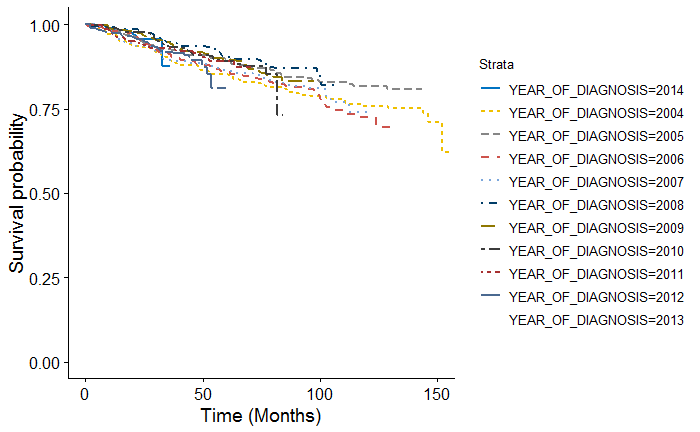

```r
uni_var(test_var = "YEAR_OF_DIAGNOSIS", data_imp = data)
```

## Primary Site

```r
#uni_var(test_var = "SITE_TEXT", data_imp = data)
```

## Histology

```r
uni_var(test_var = "HISTOLOGY_F_LIM", data_imp = data)
```

```
_________________________________________________

## HISTOLOGY_F_LIM
_________________________________________________
Call: survfit(formula = Surv(DX_LASTCONTACT_DEATH_MONTHS, PUF_VITAL_STATUS ==
    0) ~ HISTOLOGY_F_LIM, data = data)

      n  events  median 0.95LCL 0.95UCL
   3311     440      NA     152      NA

Call: survfit(formula = Surv(DX_LASTCONTACT_DEATH_MONTHS, PUF_VITAL_STATUS ==
    0) ~ HISTOLOGY_F_LIM, data = data)

 time n.risk n.event survival std.err lower 95% CI upper 95% CI
   12   3112      59    0.982 0.00237        0.977        0.986
   24   2765      78    0.956 0.00368        0.949        0.963
   36   2339      88    0.924 0.00492        0.914        0.933
   48   1966      51    0.902 0.00565        0.891        0.913
   60   1595      47    0.879 0.00646        0.866        0.891
  120    322     111    0.772 0.01185        0.749        0.796




## Univariable Cox Proportional Hazard Model for:  HISTOLOGY_F_LIM

[1] "Only one level, no Cox model performed"





## Unadjusted Kaplan Meier Overall Survival Curve for:  HISTOLOGY_F_LIM
```

## Behavior

```r
uni_var(test_var = "BEHAVIOR", data_imp = data)
```

```
_________________________________________________

## BEHAVIOR
_________________________________________________
Call: survfit(formula = Surv(DX_LASTCONTACT_DEATH_MONTHS, PUF_VITAL_STATUS ==
    0) ~ BEHAVIOR, data = data)

      n  events  median 0.95LCL 0.95UCL
   3311     440      NA     152      NA

Call: survfit(formula = Surv(DX_LASTCONTACT_DEATH_MONTHS, PUF_VITAL_STATUS ==
    0) ~ BEHAVIOR, data = data)

 time n.risk n.event survival std.err lower 95% CI upper 95% CI
   12   3112      59    0.982 0.00237        0.977        0.986
   24   2765      78    0.956 0.00368        0.949        0.963
   36   2339      88    0.924 0.00492        0.914        0.933
   48   1966      51    0.902 0.00565        0.891        0.913
   60   1595      47    0.879 0.00646        0.866        0.891
  120    322     111    0.772 0.01185        0.749        0.796




## Univariable Cox Proportional Hazard Model for:  BEHAVIOR

[1] "Only one level, no Cox model performed"





## Unadjusted Kaplan Meier Overall Survival Curve for:  BEHAVIOR
```

## Grade

```
_________________________________________________

## GRADE_F
_________________________________________________
Call: survfit(formula = Surv(DX_LASTCONTACT_DEATH_MONTHS, PUF_VITAL_STATUS ==
    0) ~ GRADE_F, data = data)

                                    n events median 0.95LCL 0.95UCL
GRADE_F=Gr I: Well Diff           926     71     NA      NA      NA
GRADE_F=Gr II: Mod Diff           319     35  152.0      NA      NA
GRADE_F=Gr III: Poor Diff         128     71   49.8    36.1    68.1
GRADE_F=Gr IV: Undiff/Anaplastic   43     24   35.3    26.6      NA
GRADE_F=NA/Unkown                1895    239     NA      NA      NA

Call: survfit(formula = Surv(DX_LASTCONTACT_DEATH_MONTHS, PUF_VITAL_STATUS ==
    0) ~ GRADE_F, data = data)

                GRADE_F=Gr I: Well Diff
 time n.risk n.event survival std.err lower 95% CI upper 95% CI
   12    879       6    0.993 0.00271        0.988        0.999
   24    789      10    0.982 0.00458        0.973        0.991
   36    671      17    0.959 0.00705        0.945        0.973
   48    533      11    0.941 0.00867        0.925        0.959
   60    428       5    0.931 0.00966        0.913        0.951
  120     90      21    0.850 0.02039        0.811        0.891

                GRADE_F=Gr II: Mod Diff
 time n.risk n.event survival std.err lower 95% CI upper 95% CI
   12    302       2    0.994 0.00453        0.985        1.000
   24    271       6    0.973 0.00939        0.955        0.992
   36    222       6    0.949 0.01327        0.924        0.976
   48    182       3    0.935 0.01539        0.905        0.966
   60    146       5    0.906 0.01967        0.868        0.945
  120     29      12    0.791 0.03711        0.722        0.867

                GRADE_F=Gr III: Poor Diff
 time n.risk n.event survival std.err lower 95% CI upper 95% CI
   12    110      13    0.895  0.0274        0.843        0.951
   24     85      17    0.751  0.0395        0.678        0.833
   36     59      16    0.600  0.0463        0.516        0.698
```

[output cut: 38 more lines]

```
GRADE_FNA/Unkown                 0.4364    1.5471   0.1352  3.227  0.00125 **
---
Signif. codes:  0 *** 0.001 ** 0.01 * 0.05 . 0.1   1

                                exp(coef) exp(-coef) lower .95 upper .95
GRADE_FGr II: Mod Diff              1.455    0.68720    0.9708     2.181
GRADE_FGr III: Poor Diff           11.473    0.08716    8.2446    15.967
GRADE_FGr IV: Undiff/Anaplastic    11.278    0.08867    7.0949    17.928
GRADE_FNA/Unkown                    1.547    0.64635    1.1869     2.017

Concordance= 0.641  (se = 0.013 )
Rsquare= 0.066   (max possible= 0.865 )
Likelihood ratio test= 225.8  on 4 df,   p=<2e-16
Wald test            = 331.3  on 4 df,   p=<2e-16
Score (logrank) test = 473.9  on 4 df,   p=<2e-16
```

```
Removed 1 rows containing missing values (geom_errorbar).
```

```
## Unadjusted Kaplan Meier Overall Survival Curve for:  GRADE_F
```

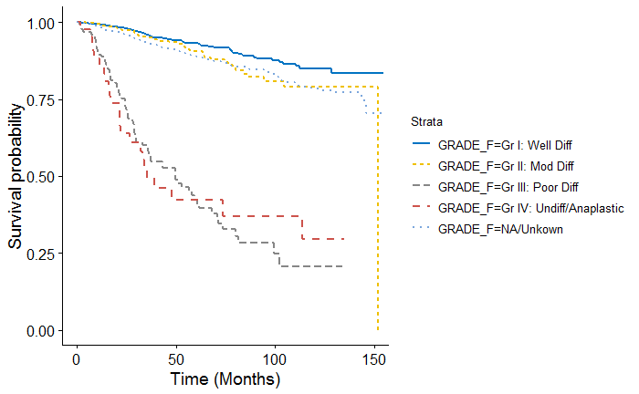

```r
uni_var(test_var = "GRADE_F", data_imp = data)
```

## Clinical T Stage

```
_________________________________________________

## TNM_CLIN_T
_________________________________________________
Call: survfit(formula = Surv(DX_LASTCONTACT_DEATH_MONTHS, PUF_VITAL_STATUS ==
    0) ~ TNM_CLIN_T, data = data)

   102 observations deleted due to missingness
                  n events median 0.95LCL 0.95UCL
TNM_CLIN_T=c0     8      1   64.4   64.43      NA
TNM_CLIN_T=c1   964     67  152.0  151.98      NA
TNM_CLIN_T=c2   789     94     NA      NA      NA
TNM_CLIN_T=c3   242     63     NA  110.32      NA
TNM_CLIN_T=c4     4      4   19.8    1.51      NA
TNM_CLIN_T=c4A   74     35   57.3   43.86      NA
TNM_CLIN_T=c4B   23     14   32.2   22.57      NA
TNM_CLIN_T=cX  1105    156     NA      NA      NA

Call: survfit(formula = Surv(DX_LASTCONTACT_DEATH_MONTHS, PUF_VITAL_STATUS ==
    0) ~ TNM_CLIN_T, data = data)

102 observations deleted due to missingness
                TNM_CLIN_T=c0
 time n.risk n.event survival std.err lower 95% CI upper 95% CI
   12      7       0        1       0            1            1
   24      7       0        1       0            1            1
   36      5       0        1       0            1            1
   48      5       0        1       0            1            1
   60      2       0        1       0            1            1

                TNM_CLIN_T=c1
 time n.risk n.event survival std.err lower 95% CI upper 95% CI
   12    916       8    0.991 0.00300        0.986        0.997
   24    809       7    0.983 0.00423        0.975        0.992
   36    687      16    0.963 0.00660        0.950        0.976
   48    578      11    0.947 0.00810        0.931        0.963
   60    456       8    0.932 0.00939        0.914        0.951
  120     71      16    0.862 0.02185        0.820        0.906

                TNM_CLIN_T=c2
```

[output cut: 74 more lines]

```

              exp(coef) exp(-coef) lower .95 upper .95
TNM_CLIN_Tc1     0.4272    2.34109   0.05928     3.078
TNM_CLIN_Tc2     0.7540    1.32624   0.10508     5.410
TNM_CLIN_Tc3     2.0410    0.48995   0.28303    14.718
TNM_CLIN_Tc4    11.1247    0.08989   1.24232    99.618
TNM_CLIN_Tc4A    3.5136    0.28461   0.48106    25.663
TNM_CLIN_Tc4B    6.6436    0.15052   0.87343    50.534
TNM_CLIN_TcX     0.7073    1.41392   0.09891     5.057

Concordance= 0.646  (se = 0.014 )
Rsquare= 0.053   (max possible= 0.869 )
Likelihood ratio test= 174.2  on 7 df,   p=<2e-16
Wald test            = 232.9  on 7 df,   p=<2e-16
Score (logrank) test = 317.7  on 7 df,   p=<2e-16
```

```
Removed 1 rows containing missing values (geom_errorbar).
```

```
## Unadjusted Kaplan Meier Overall Survival Curve for:  TNM_CLIN_T
```

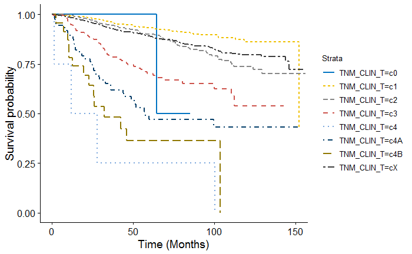

```r
uni_var(test_var = "TNM_CLIN_T", data_imp = data)
```

## Clinical N Stage

```
_________________________________________________

## TNM_CLIN_N
_________________________________________________
Call: survfit(formula = Surv(DX_LASTCONTACT_DEATH_MONTHS, PUF_VITAL_STATUS ==
    0) ~ TNM_CLIN_N, data = data)

   90 observations deleted due to missingness
                  n events median 0.95LCL 0.95UCL
TNM_CLIN_N=c0  2126    208     NA  151.98      NA
TNM_CLIN_N=c1    82     31  123.9   49.81      NA
TNM_CLIN_N=c2    22     11   34.0   21.52      NA
TNM_CLIN_N=c2A    7      3   19.8   18.30      NA
TNM_CLIN_N=c2B   46     28   38.9   26.61    57.3
TNM_CLIN_N=c2C    5      3   12.9    9.79      NA
TNM_CLIN_N=c3     2      2   22.1   11.33      NA
TNM_CLIN_N=cX   931    147     NA      NA      NA

Call: survfit(formula = Surv(DX_LASTCONTACT_DEATH_MONTHS, PUF_VITAL_STATUS ==
    0) ~ TNM_CLIN_N, data = data)

90 observations deleted due to missingness
                TNM_CLIN_N=c0
 time n.risk n.event survival std.err lower 95% CI upper 95% CI
   12   2016      15    0.993 0.00187        0.989        0.996
   24   1772      31    0.977 0.00341        0.970        0.983
   36   1470      45    0.950 0.00515        0.940        0.960
   48   1201      26    0.932 0.00617        0.920        0.944
   60    925      25    0.910 0.00737        0.896        0.925
  120    145      63    0.780 0.01820        0.745        0.817

                TNM_CLIN_N=c1
 time n.risk n.event survival std.err lower 95% CI upper 95% CI
   12     72       7    0.913  0.0315        0.853        0.977
   24     56       9    0.793  0.0463        0.707        0.889
   36     47       6    0.706  0.0532        0.609        0.818
   48     31       5    0.619  0.0594        0.513        0.747
   60     25       2    0.576  0.0625        0.466        0.713
  120      1       1    0.544  0.0667        0.428        0.692

```

[output cut: 71 more lines]

```

              exp(coef) exp(-coef) lower .95 upper .95
TNM_CLIN_Nc1      5.429    0.18421    3.7174     7.928
TNM_CLIN_Nc2      8.875    0.11267    4.8348    16.292
TNM_CLIN_Nc2A     9.851    0.10151    3.1464    30.842
TNM_CLIN_Nc2B    10.117    0.09885    6.8105    15.027
TNM_CLIN_Nc2C    16.850    0.05935    5.3806    52.765
TNM_CLIN_Nc3     29.933    0.03341    7.4068   120.971
TNM_CLIN_NcX      1.187    0.84253    0.9586     1.470

Concordance= 0.623  (se = 0.012 )
Rsquare= 0.052   (max possible= 0.868 )
Likelihood ratio test= 171.8  on 7 df,   p=<2e-16
Wald test            = 268.8  on 7 df,   p=<2e-16
Score (logrank) test = 401.5  on 7 df,   p=<2e-16
```

```
Removed 1 rows containing missing values (geom_errorbar).
```

```
## Unadjusted Kaplan Meier Overall Survival Curve for:  TNM_CLIN_N
```

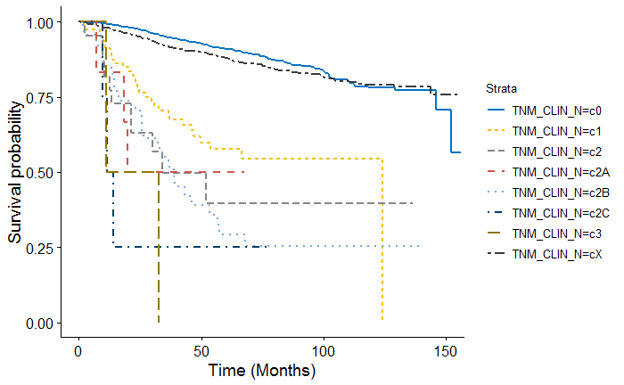

```r
uni_var(test_var = "TNM_CLIN_N", data_imp = data)
```

## Clinical M Stage

```
_________________________________________________

## TNM_CLIN_M
_________________________________________________
Call: survfit(formula = Surv(DX_LASTCONTACT_DEATH_MONTHS, PUF_VITAL_STATUS ==
    0) ~ TNM_CLIN_M, data = data)

   176 observations deleted due to missingness
                 n events median 0.95LCL 0.95UCL
TNM_CLIN_M=c0 3108    402     NA   152.0      NA
TNM_CLIN_M=c1   27     24   20.1    10.5      44

Call: survfit(formula = Surv(DX_LASTCONTACT_DEATH_MONTHS, PUF_VITAL_STATUS ==
    0) ~ TNM_CLIN_M, data = data)

176 observations deleted due to missingness
                TNM_CLIN_M=c0
 time n.risk n.event survival std.err lower 95% CI upper 95% CI
   12   2930      47    0.984 0.00226        0.980        0.989
   24   2610      72    0.959 0.00366        0.952        0.966
   36   2226      81    0.928 0.00495        0.918        0.937
   48   1892      46    0.907 0.00569        0.896        0.918
   60   1550      43    0.885 0.00649        0.872        0.898
  120    322     107    0.780 0.01187        0.757        0.804

                TNM_CLIN_M=c1
 time n.risk n.event survival std.err lower 95% CI upper 95% CI
   12     17       9    0.658  0.0926       0.4996        0.867
   24     12       4    0.498  0.0990       0.3371        0.735
   36      9       3    0.373  0.0969       0.2245        0.621
   48      6       3    0.249  0.0873       0.1252        0.495
   60      3       3    0.124  0.0670       0.0434        0.357





## Univariable Cox Proportional Hazard Model for:  TNM_CLIN_M

Call:
coxph(formula = Surv(DX_LASTCONTACT_DEATH_MONTHS, PUF_VITAL_STATUS ==
    0) ~ TNM_CLIN_M, data = data)

  n= 3135, number of events= 426
   (176 observations deleted due to missingness)

                coef exp(coef) se(coef)     z Pr(>|z|)
TNM_CLIN_Mc1  2.7694   15.9494   0.2117 13.09   <2e-16 ***
---
Signif. codes:  0 *** 0.001 ** 0.01 * 0.05 . 0.1   1

             exp(coef) exp(-coef) lower .95 upper .95
TNM_CLIN_Mc1     15.95     0.0627     10.53     24.15

Concordance= 0.532  (se = 0.002 )
Rsquare= 0.027   (max possible= 0.87 )
Likelihood ratio test= 86.39  on 1 df,   p=<2e-16
Wald test            = 171.2  on 1 df,   p=<2e-16
Score (logrank) test = 312.6  on 1 df,   p=<2e-16
```

```
Removed 1 rows containing missing values (geom_errorbar).
```

```
## Unadjusted Kaplan Meier Overall Survival Curve for:  TNM_CLIN_M
```

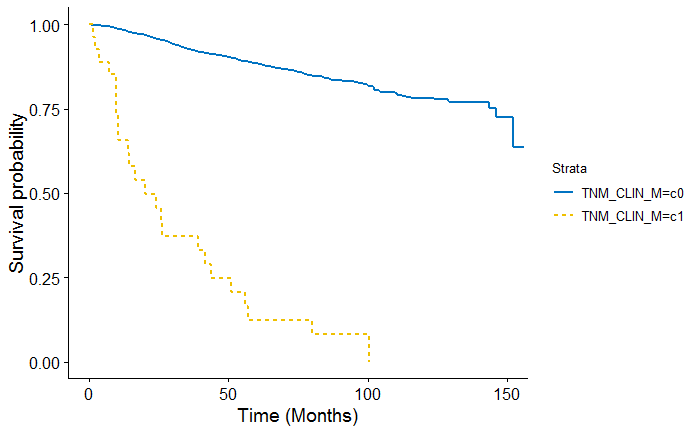

```r
uni_var(test_var = "TNM_CLIN_M", data_imp = data)
```

## Clinical Stage Group

```
_________________________________________________

## TNM_CLIN_STAGE_GROUP
_________________________________________________
Call: survfit(formula = Surv(DX_LASTCONTACT_DEATH_MONTHS, PUF_VITAL_STATUS ==
    0) ~ TNM_CLIN_STAGE_GROUP, data = data)

                           n events median 0.95LCL 0.95UCL
TNM_CLIN_STAGE_GROUP=1   942     55  152.0   152.0      NA
TNM_CLIN_STAGE_GROUP=2   747     78     NA      NA      NA
TNM_CLIN_STAGE_GROUP=3   252     58  123.9   112.4      NA
TNM_CLIN_STAGE_GROUP=4    11      8   29.8    27.7      NA
TNM_CLIN_STAGE_GROUP=4A  117     49   68.1    43.9      NA
TNM_CLIN_STAGE_GROUP=4B   24     14   42.2    22.6      NA
TNM_CLIN_STAGE_GROUP=4C   22     20   16.6    10.5    41.6
TNM_CLIN_STAGE_GROUP=99 1196    158     NA      NA      NA

Call: survfit(formula = Surv(DX_LASTCONTACT_DEATH_MONTHS, PUF_VITAL_STATUS ==
    0) ~ TNM_CLIN_STAGE_GROUP, data = data)

                TNM_CLIN_STAGE_GROUP=1
 time n.risk n.event survival std.err lower 95% CI upper 95% CI
   12    899       5    0.995 0.00243        0.990        0.999
   24    795       6    0.988 0.00372        0.980        0.995
   36    678      15    0.968 0.00626        0.955        0.980
   48    574       5    0.960 0.00704        0.947        0.974
   60    450       7    0.948 0.00843        0.931        0.964
  120     75      16    0.878 0.02114        0.838        0.920

                TNM_CLIN_STAGE_GROUP=2
 time n.risk n.event survival std.err lower 95% CI upper 95% CI
   12    715       1    0.999 0.00138        0.996        1.000
   24    646       9    0.986 0.00448        0.977        0.995
   36    538      15    0.961 0.00761        0.946        0.976
   48    433       9    0.944 0.00949        0.925        0.962
   60    343       9    0.922 0.01170        0.899        0.945
  120     57      34    0.741 0.03244        0.680        0.807

                TNM_CLIN_STAGE_GROUP=3
 time n.risk n.event survival std.err lower 95% CI upper 95% CI
```

[output cut: 71 more lines]

```

                       exp(coef) exp(-coef) lower .95 upper .95
TNM_CLIN_STAGE_GROUP2      1.819    0.54979     1.288     2.569
TNM_CLIN_STAGE_GROUP3      4.854    0.20600     3.355     7.023
TNM_CLIN_STAGE_GROUP4     23.681    0.04223    11.264    49.785
TNM_CLIN_STAGE_GROUP4A     9.616    0.10399     6.539    14.141
TNM_CLIN_STAGE_GROUP4B    17.151    0.05831     9.528    30.873
TNM_CLIN_STAGE_GROUP4C    41.887    0.02387    25.034    70.085
TNM_CLIN_STAGE_GROUP99     1.964    0.50927     1.444     2.671

Concordance= 0.694  (se = 0.014 )
Rsquare= 0.082   (max possible= 0.865 )
Likelihood ratio test= 281.9  on 7 df,   p=<2e-16
Wald test            = 399  on 7 df,   p=<2e-16
Score (logrank) test = 667.9  on 7 df,   p=<2e-16
```

```
Removed 1 rows containing missing values (geom_errorbar).
```

```
## Unadjusted Kaplan Meier Overall Survival Curve for:  TNM_CLIN_STAGE_GROUP
```

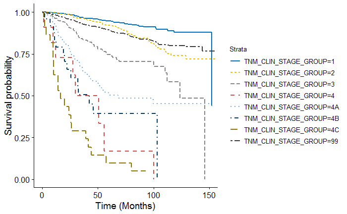

```r
uni_var(test_var = "TNM_CLIN_STAGE_GROUP", data_imp = data)
```

## Pathologic T Stage

```
_________________________________________________

## TNM_PATH_T
_________________________________________________
Call: survfit(formula = Surv(DX_LASTCONTACT_DEATH_MONTHS, PUF_VITAL_STATUS ==
    0) ~ TNM_PATH_T, data = data)

   102 observations deleted due to missingness
                  n events median 0.95LCL 0.95UCL
TNM_PATH_T=p0     7      0     NA      NA      NA
TNM_PATH_T=p1  1140     82  152.0   152.0      NA
TNM_PATH_T=p2   892    116     NA      NA      NA
TNM_PATH_T=p3   307     87  110.3    84.0      NA
TNM_PATH_T=p4     4      1  100.4   100.4      NA
TNM_PATH_T=p4A  100     42   62.2    49.5      NA
TNM_PATH_T=p4B   20      9  103.5    25.8      NA
TNM_PATH_T=pX   739     93     NA      NA      NA

Call: survfit(formula = Surv(DX_LASTCONTACT_DEATH_MONTHS, PUF_VITAL_STATUS ==
    0) ~ TNM_PATH_T, data = data)

102 observations deleted due to missingness
                TNM_PATH_T=p0
 time n.risk n.event survival std.err lower 95% CI upper 95% CI
   12      7       0        1       0            1            1
   24      7       0        1       0            1            1
   36      7       0        1       0            1            1
   48      6       0        1       0            1            1
   60      4       0        1       0            1            1

                TNM_PATH_T=p1
 time n.risk n.event survival std.err lower 95% CI upper 95% CI
   12   1079       9    0.992 0.00269        0.987        0.997
   24    942      12    0.980 0.00430        0.972        0.989
   36    804      17    0.961 0.00617        0.949        0.974
   48    665       9    0.950 0.00721        0.936        0.964
   60    504       9    0.935 0.00855        0.919        0.952
  120     84      25    0.838 0.02243        0.795        0.883

                TNM_PATH_T=p2
```

[output cut: 43 more lines]

```

                TNM_PATH_T=pX
 time n.risk n.event survival std.err lower 95% CI upper 95% CI
   12    706      18    0.975 0.00576        0.964        0.987
   24    675      12    0.958 0.00742        0.944        0.973
   36    629      14    0.938 0.00904        0.921        0.956
   48    603      10    0.923 0.01007        0.904        0.943
   60    566      11    0.906 0.01114        0.884        0.928
  120    148      25    0.844 0.01653        0.812        0.877





## Univariable Cox Proportional Hazard Model for:  TNM_PATH_T
```

```
Loglik converged before variable  1,2,3,4,5,6,7 ; beta may be infinite.
```

```
Call:
coxph(formula = Surv(DX_LASTCONTACT_DEATH_MONTHS, PUF_VITAL_STATUS ==
    0) ~ TNM_PATH_T, data = data)

  n= 3209, number of events= 430
   (102 observations deleted due to missingness)

                   coef exp(coef)  se(coef)     z Pr(>|z|)
TNM_PATH_Tp1  1.308e+01 4.812e+05 8.722e+02 0.015    0.988
TNM_PATH_Tp2  1.370e+01 8.906e+05 8.722e+02 0.016    0.987
TNM_PATH_Tp3  1.470e+01 2.420e+06 8.722e+02 0.017    0.987
TNM_PATH_Tp4  1.394e+01 1.131e+06 8.722e+02 0.016    0.987
TNM_PATH_Tp4A 1.509e+01 3.579e+06 8.722e+02 0.017    0.986
TNM_PATH_Tp4B 1.523e+01 4.132e+06 8.722e+02 0.017    0.986
TNM_PATH_TpX  1.326e+01 5.720e+05 8.722e+02 0.015    0.988

              exp(coef) exp(-coef) lower .95 upper .95
TNM_PATH_Tp1     481151  2.078e-06         0       Inf
TNM_PATH_Tp2     890582  1.123e-06         0       Inf
TNM_PATH_Tp3    2420346  4.132e-07         0       Inf
TNM_PATH_Tp4    1131204  8.840e-07         0       Inf
TNM_PATH_Tp4A   3578659  2.794e-07         0       Inf
TNM_PATH_Tp4B   4131699  2.420e-07         0       Inf
TNM_PATH_TpX     572036  1.748e-06         0       Inf

Concordance= 0.666  (se = 0.014 )
Rsquare= 0.057   (max possible= 0.866 )
Likelihood ratio test= 189.8  on 7 df,   p=<2e-16
Wald test            = 224.9  on 7 df,   p=<2e-16
Score (logrank) test = 278.1  on 7 df,   p=<2e-16
```

[output not shown]

```
## Unadjusted Kaplan Meier Overall Survival Curve for:  TNM_PATH_T
```

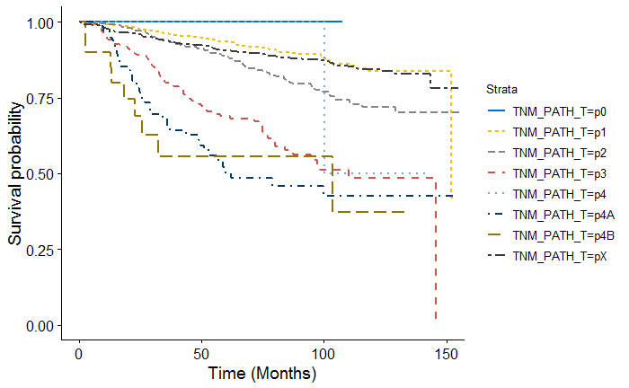

```r
uni_var(test_var = "TNM_PATH_T", data_imp = data)
```

## Pathologic N Stage

```
_________________________________________________

## TNM_PATH_N
_________________________________________________
Call: survfit(formula = Surv(DX_LASTCONTACT_DEATH_MONTHS, PUF_VITAL_STATUS ==
    0) ~ TNM_PATH_N, data = data)

   165 observations deleted due to missingness
                  n events median 0.95LCL 0.95UCL
TNM_PATH_N=p0  1907    198     NA   152.0      NA
TNM_PATH_N=p1   112     35     NA    73.6      NA
TNM_PATH_N=p2    11      6  36.73    24.2      NA
TNM_PATH_N=p2A   11      6  51.84    18.3      NA
TNM_PATH_N=p2B   94     52  43.37    32.2    63.5
TNM_PATH_N=p2C    1      1   2.56      NA      NA
TNM_PATH_N=pX  1010    130     NA      NA      NA

Call: survfit(formula = Surv(DX_LASTCONTACT_DEATH_MONTHS, PUF_VITAL_STATUS ==
    0) ~ TNM_PATH_N, data = data)

165 observations deleted due to missingness
                TNM_PATH_N=p0
 time n.risk n.event survival std.err lower 95% CI upper 95% CI
   12   1805      13    0.993 0.00195        0.989        0.997
   24   1598      29    0.976 0.00363        0.969        0.983
   36   1327      39    0.951 0.00538        0.940        0.961
   48   1098      23    0.933 0.00643        0.920        0.946
   60    846      24    0.910 0.00779        0.895        0.925
  120    154      68    0.775 0.01807        0.740        0.811

                TNM_PATH_N=p1
 time n.risk n.event survival std.err lower 95% CI upper 95% CI
   12    102       5    0.954  0.0202        0.915        0.994
   24     89       6    0.896  0.0297        0.840        0.956
   36     70       8    0.809  0.0396        0.735        0.891
   48     51       9    0.699  0.0485        0.610        0.800
   60     41       2    0.671  0.0504        0.579        0.777
  120      6       5    0.562  0.0618        0.454        0.698

                TNM_PATH_N=p2
```

[output cut: 58 more lines]

```
Signif. codes:  0 *** 0.001 ** 0.01 * 0.05 . 0.1   1

              exp(coef) exp(-coef) lower .95 upper .95
TNM_PATH_Np1     3.5894    0.27860    2.5046     5.144
TNM_PATH_Np2     7.5851    0.13184    3.3658    17.094
TNM_PATH_Np2A   10.2683    0.09739    4.5492    23.177
TNM_PATH_Np2B    8.8840    0.11256    6.5309    12.085
TNM_PATH_Np2C  534.6802    0.00187   66.6805  4287.355
TNM_PATH_NpX     0.9696    1.03140    0.7762     1.211

Concordance= 0.601  (se = 0.013 )
Rsquare= 0.06   (max possible= 0.87 )
Likelihood ratio test= 196.2  on 6 df,   p=<2e-16
Wald test            = 306.1  on 6 df,   p=<2e-16
Score (logrank) test = 733.6  on 6 df,   p=<2e-16
```

```
Removed 1 rows containing missing values (geom_errorbar).
```

```
## Unadjusted Kaplan Meier Overall Survival Curve for:  TNM_PATH_N
```

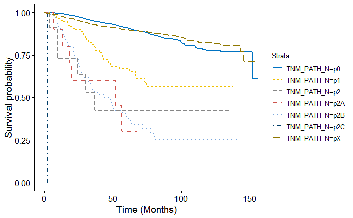

```r
uni_var(test_var = "TNM_PATH_N", data_imp = data)
```

## Pathologic M Stage

```
_________________________________________________

## TNM_PATH_M
_________________________________________________
Call: survfit(formula = Surv(DX_LASTCONTACT_DEATH_MONTHS, PUF_VITAL_STATUS ==
    0) ~ TNM_PATH_M, data = data)

   1590 observations deleted due to missingness
                 n events median 0.95LCL 0.95UCL
TNM_PATH_M=p1   13     12   19.3     7.2      NA
TNM_PATH_M=pX 1708    298     NA   152.0      NA

Call: survfit(formula = Surv(DX_LASTCONTACT_DEATH_MONTHS, PUF_VITAL_STATUS ==
    0) ~ TNM_PATH_M, data = data)

1590 observations deleted due to missingness
                TNM_PATH_M=p1
 time n.risk n.event survival std.err lower 95% CI upper 95% CI
   12      8       5    0.615   0.135        0.400        0.946
   24      5       3    0.385   0.135        0.193        0.765
   36      5       0    0.385   0.135        0.193        0.765
   48      5       0    0.385   0.135        0.193        0.765
   60      2       3    0.154   0.100        0.043        0.550

                TNM_PATH_M=pX
 time n.risk n.event survival std.err lower 95% CI upper 95% CI
   12   1636      27    0.984 0.00307        0.978        0.990
   24   1565      45    0.957 0.00500        0.947        0.966
   36   1467      54    0.923 0.00658        0.910        0.936
   48   1393      31    0.903 0.00733        0.889        0.918
   60   1296      31    0.883 0.00804        0.867        0.899
  120    322     104    0.777 0.01264        0.753        0.803





## Univariable Cox Proportional Hazard Model for:  TNM_PATH_M

Call:
coxph(formula = Surv(DX_LASTCONTACT_DEATH_MONTHS, PUF_VITAL_STATUS ==
    0) ~ TNM_PATH_M, data = data)

  n= 1721, number of events= 310
   (1590 observations deleted due to missingness)

                coef exp(coef) se(coef)      z Pr(>|z|)
TNM_PATH_MpX -2.6809    0.0685   0.2967 -9.035   <2e-16 ***
---
Signif. codes:  0 *** 0.001 ** 0.01 * 0.05 . 0.1   1

             exp(coef) exp(-coef) lower .95 upper .95
TNM_PATH_MpX    0.0685       14.6   0.03829    0.1225

Concordance= 0.521  (se = 0.002 )
Rsquare= 0.024   (max possible= 0.922 )
Likelihood ratio test= 41.41  on 1 df,   p=1e-10
Wald test            = 81.63  on 1 df,   p=<2e-16
Score (logrank) test = 143.8  on 1 df,   p=<2e-16
```

```
Removed 1 rows containing missing values (geom_errorbar).
```

```
## Unadjusted Kaplan Meier Overall Survival Curve for:  TNM_PATH_M
```

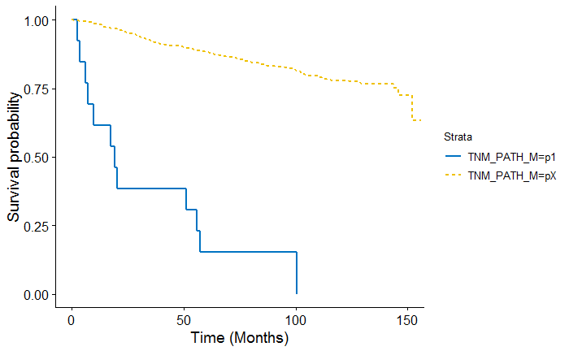

```r
uni_var(test_var = "TNM_PATH_M", data_imp = data)
```

## Pathologic Stage Group

```
_________________________________________________

## TNM_PATH_STAGE_GROUP
_________________________________________________
Call: survfit(formula = Surv(DX_LASTCONTACT_DEATH_MONTHS, PUF_VITAL_STATUS ==
    0) ~ TNM_PATH_STAGE_GROUP, data = data)

   88 observations deleted due to missingness
                           n events median 0.95LCL 0.95UCL
TNM_PATH_STAGE_GROUP=1  1112     63  152.0  151.98      NA
TNM_PATH_STAGE_GROUP=2   842     83     NA      NA      NA
TNM_PATH_STAGE_GROUP=3   350     78  145.9  123.89      NA
TNM_PATH_STAGE_GROUP=4     8      6   46.4   29.83      NA
TNM_PATH_STAGE_GROUP=4A  185     77   78.0   56.74      NA
TNM_PATH_STAGE_GROUP=4B   19      8  103.5   25.79      NA
TNM_PATH_STAGE_GROUP=4C   15     13   17.3    9.79    57.3
TNM_PATH_STAGE_GROUP=99  692    104     NA      NA      NA

Call: survfit(formula = Surv(DX_LASTCONTACT_DEATH_MONTHS, PUF_VITAL_STATUS ==
    0) ~ TNM_PATH_STAGE_GROUP, data = data)

88 observations deleted due to missingness
                TNM_PATH_STAGE_GROUP=1
 time n.risk n.event survival std.err lower 95% CI upper 95% CI
   12   1064       7    0.994 0.00242        0.989        0.998
   24    954       8    0.986 0.00365        0.979        0.993
   36    837      10    0.975 0.00495        0.965        0.985
   48    723       6    0.968 0.00575        0.956        0.979
   60    579       9    0.954 0.00716        0.941        0.969
  120    110      21    0.880 0.01857        0.845        0.917

                TNM_PATH_STAGE_GROUP=2
 time n.risk n.event survival std.err lower 95% CI upper 95% CI
   12    805       1    0.999 0.00123        0.996        1.000
   24    723       8    0.988 0.00385        0.981        0.996
   36    607      18    0.962 0.00720        0.948        0.976
   48    497       9    0.946 0.00876        0.929        0.964
   60    404       9    0.927 0.01067        0.907        0.948
  120     89      37    0.787 0.02492        0.740        0.837

```

[output cut: 76 more lines]

```

                       exp(coef) exp(-coef) lower .95 upper .95
TNM_PATH_STAGE_GROUP2      1.793    0.55767     1.292     2.488
TNM_PATH_STAGE_GROUP3      4.742    0.21090     3.401     6.610
TNM_PATH_STAGE_GROUP4     15.756    0.06347     6.818    36.409
TNM_PATH_STAGE_GROUP4A     9.888    0.10113     7.083    13.803
TNM_PATH_STAGE_GROUP4B    10.750    0.09302     5.150    22.440
TNM_PATH_STAGE_GROUP4C    39.405    0.02538    21.638    71.759
TNM_PATH_STAGE_GROUP99     2.617    0.38208     1.914     3.579

Concordance= 0.72  (se = 0.014 )
Rsquare= 0.082   (max possible= 0.867 )
Likelihood ratio test= 276.1  on 7 df,   p=<2e-16
Wald test            = 331.5  on 7 df,   p=<2e-16
Score (logrank) test = 494.2  on 7 df,   p=<2e-16
```

```
Removed 1 rows containing missing values (geom_errorbar).
```

```
## Unadjusted Kaplan Meier Overall Survival Curve for:  TNM_PATH_STAGE_GROUP
```

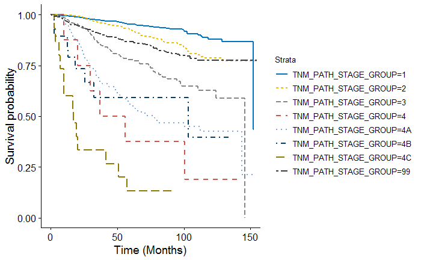

```r
uni_var(test_var = "TNM_PATH_STAGE_GROUP", data_imp = data)
```